# ECS530: (VIII) Spatial multilevel regression

Roger Bivand

Thursday 5 December 2019, 13:15-15.00, aud. C

### Copyright

All the material presented here, to the extent it is original, is available under [CC-BY-SA](https://creativecommons.org/licenses/by-sa/4.0/). Parts build on joint tutorials with Edzer Pebesma.

### Required current contributed CRAN packages:

I am running R 3.6.1, with recent `update.packages()`.

```r
needed <- c("coda", "INLABMA", "INLA", "ggplot2", "R2BayesX", "colorspace", "BayesXsrc", "HSAR", "hglm", "MatrixModels", "lme4", "spdep", "sp", "tmap", "spData", "sf")
```

### Script

Script and data at https://github.com/rsbivand/ECS530_h19/raw/master/ECS530_VIII.zip. Download to suitable location, unzip and use as basis.

## Schedule

- 2/12 (I) Spatial data representation, (II) Support+topology, input/output
- 3/12 (III) Coordinate reference systems, (IV) Visualization
- 4/12 (VI) Spatial autocorrelation, *project surgery*
- 5/12 (VII) Spatial regression, **(VIII) Spatial multilevel regression**
- 6/12 (IX) Interpolation, point processes, *project surgery*
- 7/12 *Presentations*

## Session VIII

- 13:15-13:45 Introduction, Boston data set (II)
- 13:45-14:30 Multilevel Boston
- 14:30-15:00 Bayesian spatial econometrics

# Multilevel Boston

### Reading the shapefile

Functions in **sf** are prefixed with `st_` meaning spatio-temporal (following PostGIS); `sf::st_read` uses GDAL vector drivers:

```r
library(sf)
library(spData)
b506 <- st_read(system.file("shapes/boston_tracts.shp", package="spData")[1])
```

### Aggregating geometries to model output zones

After dropping the censored census tracts, we need to derive the model output zones. The aggregate method calls `sf::st_union` on each unique grouping value, but the function called internally is a trick, putting only the first value of each variable in the output; for this reason we only retain the ids:

```r
b489 <- b506[b506$censored == "no",]
t0 <- aggregate(b489, list(ids = b489$NOX_ID), head, n = 1)
b94 <- t0[, c("ids", attr(t0, "sf_column"))]
```

### Finding model output zones neighbours

We can find contiguous neighbours using `sf::st_relate`, but this does not yet scale to large numbers of geometries; we also find a no-neighbour model output zone:

```r
st_queen <- function(a, b = a) st_relate(a, b, pattern = "F***T****")
qm1 <- st_queen(b94)
```

```
## although coordinates are longitude/latitude, st_relate_pattern assumes that they are planar
```

```r
any(sapply(qm1, length) == 0)
```

```
## [1] TRUE
```

### Problem of no-neighbour zone

Both Bayesian multilevel spatial model fitting approaches fail on the no-neighbour case (the spatially structured random effect cannot be estimated), so we need to drop those census tracts and re-aggregate to model output zones with neighbours:

```r
NOX_ID_no_neighs <- b94$ids[which(sapply(qm1, length) == 0)]
b487 <- b489[is.na(match(b489$NOX_ID, NOX_ID_no_neighs)),]
t0 <- aggregate(b487, list(ids = b487$NOX_ID), head, n = 1)
b93 <- t0[, c("ids", attr(t0, "sf_column"))]
```

and finally create the same kind of `nb` object as used in **spdep**:

```r
qm_93 <- st_queen(b93)
```

```
## although coordinates are longitude/latitude, st_relate_pattern assumes that they are planar
```

```r
class(qm_93) <- "nb"
attr(qm_93, "region.id") <- as.character(b93$ids)
```

### NOX values (parts per 10 million)

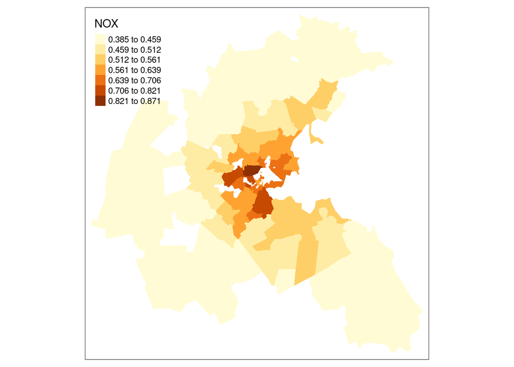

```r
library(tmap)
tm_shape(b487) + tm_fill("NOX", n=7, style="fisher")
```

## Multilevel spatial models

The ZN, INDUS, NOX, RAD, TAX and PTRATIO variables show effectively no variability within the TASSIM zones, so in a multilevel model the random effect may absorb their influence. The model as a whole, before introducing random effects, is:

```r
form <- formula(log(median) ~ CRIM + ZN + INDUS + CHAS + I((NOX*10)^2) + I(RM^2) +
  AGE + log(DIS) + log(RAD) + TAX + PTRATIO + I(BB/100) + log(I(LSTAT/100)))
```

### Empirical approach

We will be using row-standardised contiguity neighbours derived from the map of census tracts, and from the map of merged census tracts constituting approximate TASSIM zones

```r
q487 <- st_queen(lwgeom::st_make_valid(b487))
q487[which(sapply(q487, length) == 0)] <- 0L
class(q487) <- "nb"
suppressPackageStartupMessages(library(spdep))
lw487 <- nb2listw(q487, zero.policy=TRUE)
```

### Model comparisons

This is not completed as a proper set of comparisons with this data set - (Bivand et al. 2017; Bivand 2017) contains comparisons for Beijing land parcels and a housing data set for SW Norway. The baseline tract level residual spatial autocorrelation is measured using a proper Moran test (b487 is an `sf` object):

```r
OLS <- lm(form, data=b487)
lm.morantest(OLS, lw487, alternative="two.sided", zero.policy=TRUE)
```

```
##
##  Global Moran I for regression residuals
##
## data:
## model: lm(formula = form, data = b487)
## weights: lw487
##
## Moran I statistic standard deviate = 15.898, p-value < 2.2e-16
## alternative hypothesis: two.sided
## sample estimates:
## Observed Moran I      Expectation         Variance
##     0.4165620055    -0.0168821367     0.0007433579
```

### Linear Mixed Effects

Here we fit air pollution model output zone unstructured random effects using **lme4**, and the residual spatial autocorrelation falls (indicative not proper test):

```r
library(lme4)
MLM <- lmer(update(form, . ~ . + (1 | NOX_ID)), data=b487, REML=FALSE)
moran.test(residuals(MLM), lw487, alternative="two.sided", zero.policy=TRUE)
```

```
##
##  Moran I test under randomisation
##
## data:  residuals(MLM)
## weights: lw487  n reduced by no-neighbour observations
##
##
## Moran I statistic standard deviate = 2.0662, p-value = 0.03881
## alternative hypothesis: two.sided
## sample estimates:
## Moran I statistic       Expectation          Variance
##      0.0555611072     -0.0020618557      0.0007777858
```

```r
b93$MLM_re <- ranef(MLM)[[1]][,1]
```

### Data setup

Both **hglm** and **HSAR** need sparse design matrices precomputed:

```r
library(Matrix)
suppressMessages(library(MatrixModels))
Delta <- as(model.Matrix(~ -1 + as.factor(NOX_ID), data=b487, sparse=TRUE), "dgCMatrix")
M <- as(nb2listw(qm_93, style="B"), "CsparseMatrix")
```

### Using HGLM

Fitting the air pollution model output zone unstructured random effects using hierarchical GLM also works (indicative test):

```r
library(hglm)
y_hglm <- log(b487$median)
X_hglm <- model.matrix(OLS)
suppressWarnings(HGLM_iid <- hglm(y=y_hglm, X=X_hglm, Z=Delta))
moran.test(HGLM_iid$resid, lw487, alternative="two.sided", zero.policy=TRUE)
```

```
##
##  Moran I test under randomisation
##
## data:  HGLM_iid$resid
## weights: lw487  n reduced by no-neighbour observations
##
##
## Moran I statistic standard deviate = 1.9175, p-value = 0.05518
## alternative hypothesis: two.sided
## sample estimates:
## Moran I statistic       Expectation          Variance
##      0.0514037549     -0.0020618557      0.0007774949
```

As does a Simultaneous Autoregressive (SAR) fitted with **hglm**, modelling with air pollution model output zone spatially structured random effects:

```r
HGLM_sar <- hglm(y=y_hglm, X=X_hglm, Z=Delta, rand.family=SAR(D=M))
moran.test(HGLM_sar$resid, lw487, alternative="two.sided", zero.policy=TRUE)
```

```
##
##  Moran I test under randomisation
##
## data:  HGLM_sar$resid
## weights: lw487  n reduced by no-neighbour observations
##
##
## Moran I statistic standard deviate = 1.7161, p-value = 0.08614
## alternative hypothesis: two.sided
## sample estimates:
## Moran I statistic       Expectation          Variance
##      0.0457782452     -0.0020618557      0.0007771106
```

```r
b93$HGLM_re <- unname(HGLM_iid$ranef)
b93$HGLM_ss <- HGLM_sar$ranef[,1]
```

## Unstructured random effects: TASSIM zones

```r
brks <- seq(-0.6, 0.6, 0.15)
tm_shape(b93) + tm_fill(c("MLM_re", "HGLM_re"), breaks=brks)
```

```
## Variable "MLM_re" contains positive and negative values, so midpoint is set to 0. Set midpoint = NA to show the full spectrum of the color palette.
```

```
## Variable "HGLM_re" contains positive and negative values, so midpoint is set to 0. Set midpoint = NA to show the full spectrum of the color palette.
```

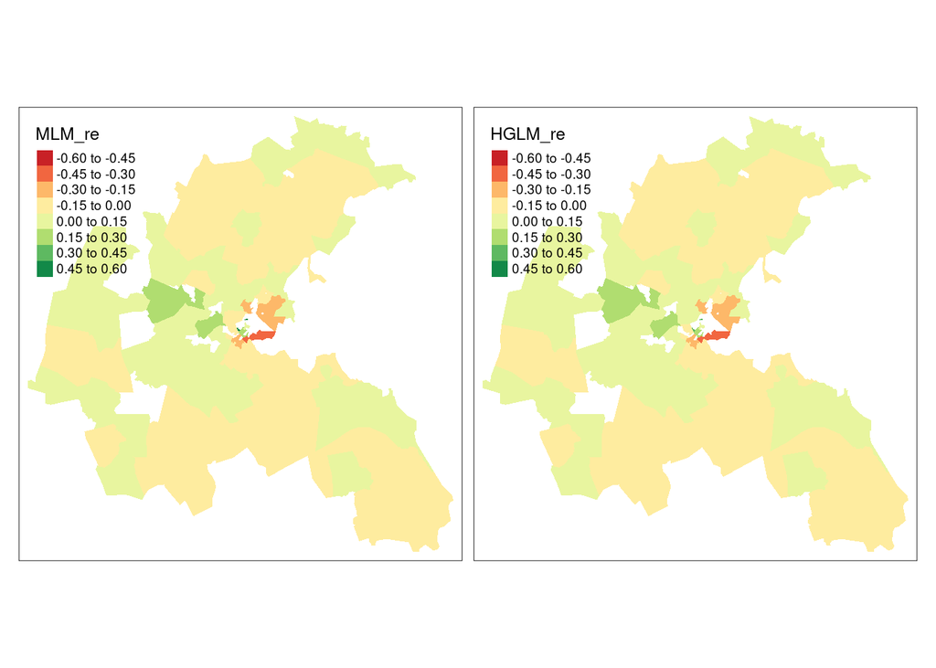

### Using HSAR

**HSAR** fits the model with air pollution model output zone spatially structured random effects using MCMC:

```r
library(HSAR)
HSAR <- hsar(form, data=b487, W=NULL, M=M, Delta=Delta,
             burnin=500, Nsim=5000, thinning=1)
```

[output not shown]

[output cut: 3726 more lines]

[output not shown]

```r
b93$HSAR_ss <- HSAR$Mus[1,]
```

### Spatially structured random effects: TASSIM zones

```r
tm_shape(b93) + tm_fill(c("HGLM_ss", "HSAR_ss"), breaks=brks)
```

```
## Variable "HGLM_ss" contains positive and negative values, so midpoint is set to 0. Set midpoint = NA to show the full spectrum of the color palette.
```

```
## Variable "HSAR_ss" contains positive and negative values, so midpoint is set to 0. Set midpoint = NA to show the full spectrum of the color palette.
```

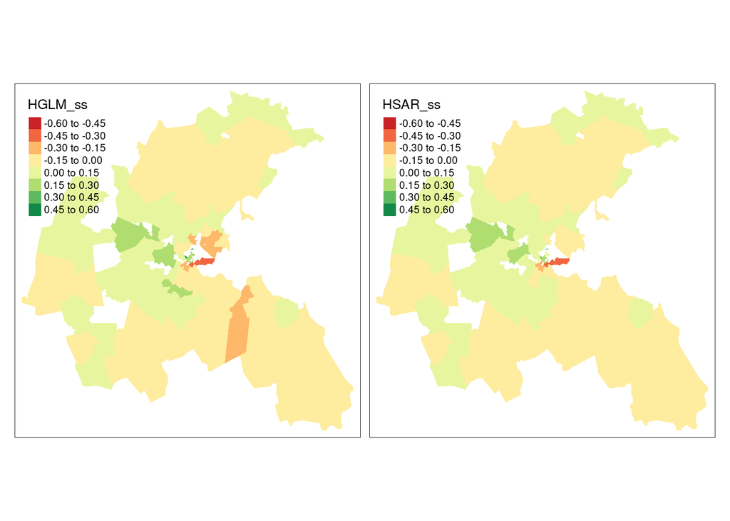

### Using R2BayesX

We can use **R2BayesX** for the same purposes, for both unstructured and spatially structured random effects by MCMC:

```r
suppressPackageStartupMessages(library(R2BayesX))
BX_iid <- bayesx(update(form, . ~ . + sx(NOX_ID, bs="re")), family="gaussian",
data=b487, method="MCMC", iterations=12000, burnin=2000, step=2, seed=123)
moran.test(residuals(BX_iid), lw487, alternative="two.sided", zero.policy=TRUE)
```

```
##
##  Moran I test under randomisation
##
## data:  residuals(BX_iid)
## weights: lw487  n reduced by no-neighbour observations
##
##
## Moran I statistic standard deviate = 1.9259, p-value = 0.05411
## alternative hypothesis: two.sided
## sample estimates:
## Moran I statistic       Expectation          Variance
##      0.0516469469     -0.0020618557      0.0007776892
```

```r
b93$BX_re <- BX_iid$effects["sx(NOX_ID):re"][[1]]$Mean
```

The spatially structured random effects are modelled as an intrinsic Conditional Autoregressive (CAR), not a SAR with a parameter, but turn out very similar:

```r
RBX_gra <- nb2gra(qm_93)
BX_mrf <- bayesx(update(form, . ~ . + sx(NOX_ID, bs="mrf", map=RBX_gra)),
family="gaussian", data=b487, method="MCMC", iterations=12000, burnin=2000,
step=2, seed=123)
moran.test(residuals(BX_mrf), lw487, alternative="two.sided", zero.policy=TRUE)
```

```
##
##  Moran I test under randomisation
##
## data:  residuals(BX_mrf)
## weights: lw487  n reduced by no-neighbour observations
##
##
## Moran I statistic standard deviate = 1.8493, p-value = 0.06442
## alternative hypothesis: two.sided
## sample estimates:
## Moran I statistic       Expectation          Variance
##      0.0495021079     -0.0020618557      0.0007774822
```

```r
b93$BX_ss <- BX_mrf$effects["sx(NOX_ID):mrf"][[1]]$Mean
```

## BayesX separate model random effects

```r
tm_shape(b93) +  tm_fill(c("BX_re", "BX_ss"), breaks=brks)
```

```
## Variable "BX_re" contains positive and negative values, so midpoint is set to 0. Set midpoint = NA to show the full spectrum of the color palette.
```

```
## Variable "BX_ss" contains positive and negative values, so midpoint is set to 0. Set midpoint = NA to show the full spectrum of the color palette.
```

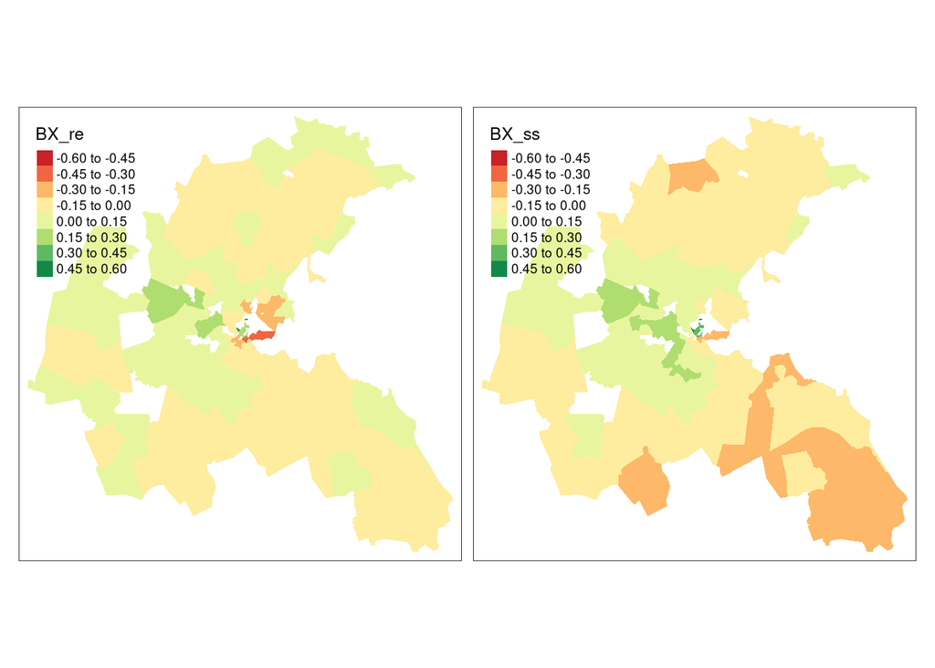

### BYM with BayesX

Combining the CAR and unstructured random effects in one model is the Besag, York, Mollie (BYM) model:

```r
b487$d_id <- as.integer(as.factor(b487$NOX_ID))
BX_bym <- bayesx(update(form, . ~ . + sx(NOX_ID, bs="mrf", map=RBX_gra) +
sx(d_id, bs="re")), family="gaussian", data=b487, method="MCMC",
iterations=12000, burnin=2000, step=2, seed=123)
moran.test(residuals(BX_bym), lw487, alternative="two.sided", zero.policy=TRUE)
```

```
##
##  Moran I test under randomisation
##
## data:  residuals(BX_bym)
## weights: lw487  n reduced by no-neighbour observations
##
##
## Moran I statistic standard deviate = 1.7971, p-value = 0.07231
## alternative hypothesis: two.sided
## sample estimates:
## Moran I statistic       Expectation          Variance
##       0.048050686      -0.002061856       0.000777544
```

```r
b93$BX_ss_bym <- BX_bym$effects["sx(NOX_ID):mrf"][[1]]$Mean
b93$BX_re_bym <- BX_bym$effects["sx(d_id):re"][[1]]$Mean
```

### BayesX BYM random effects

```r
tm_shape(b93) + tm_fill(c("BX_re_bym", "BX_ss_bym"), breaks=brks)
```

```
## Variable "BX_re_bym" contains positive and negative values, so midpoint is set to 0. Set midpoint = NA to show the full spectrum of the color palette.
```

```
## Variable "BX_ss_bym" contains positive and negative values, so midpoint is set to 0. Set midpoint = NA to show the full spectrum of the color palette.
```

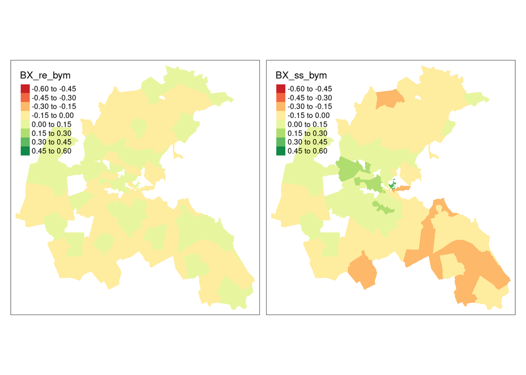

### NOX coefficients

Looking at the NOX coefficients alone is disappointing, but recall that the upper level random effects do apply to NOX too so we could map their standard errors of which some are small compared to the effects:

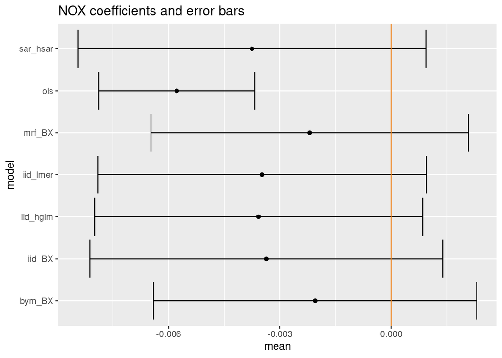

```r
library(ggplot2)
df_res <- as.data.frame(res)
names(df_res) <- c("mean", "sd")
limits <- aes(ymax = mean + qnorm(0.975)*sd, ymin=mean + qnorm(0.025)*sd)
df_res$model <- row.names(df_res)
p <- ggplot(df_res, aes(y=mean, x=model)) + geom_point() + geom_errorbar(limits) + geom_hline(yintercept = 0, col="#EB811B") + coord_flip()
p + ggtitle("NOX coefficients and error bars") + theme(plot.background = element_rect(fill = "transparent",colour = NA), legend.background = element_rect(colour = NA, fill = "transparent"))
```

# Bayesian spatial econometrics

```r
library(spdep)
```

```r
# install INLA
# install.packages("INLA", repos="https://inla.r-inla-download.org/R/stable")
library(INLA)
library(INLABMA)
```

### Columbus toy data

```r
data(oldcol)
lw <- nb2listw(COL.nb, style="W")
ev <- eigenw(similar.listw(lw))
W <- listw2mat(lw)
sW <- as(lw, "CsparseMatrix")
tr <- trW(sW)
m.form <-  CRIME ~ INC + HOVAL
COL.OLD$LAG_INC <- lag(lw, COL.OLD$INC)
COL.OLD$LAG_HOVAL <- lag(lw, COL.OLD$HOVAL)
COL.OLD$idx <- 1:nrow(COL.OLD)
dm.form <- CRIME ~ INC + HOVAL + LAG_INC + LAG_HOVAL
```

### Simulation framework

```r
titer <- 2000L
nomit <- 1000L
niter <- titer - nomit
thin <- 1L
```

### Check Durbin

```r
coefficients(lmSLX(m.form, data=COL.OLD, listw=lw))
```

```
## (Intercept)         INC       HOVAL     lag.INC   lag.HOVAL
##  75.0287479  -1.1089293  -0.2897283  -1.3709725   0.1917608
```

```r
coefficients(lm(dm.form, data=COL.OLD))
```

```
## (Intercept)         INC       HOVAL     LAG_INC   LAG_HOVAL
##  75.0287479  -1.1089293  -0.2897283  -1.3709725   0.1917608
```

### Try hglm

```r
library(hglm)
suppressWarnings(sem.hglm <- hglm(fixed=m.form, random= ~ 1 | I(as.factor(idx)),
                data=COL.OLD, rand.family=SAR(D=sW), sparse=TRUE, verbose=FALSE))
```

### HGLM SEM

```r
summary(sem.hglm)
```

```
## Call:
## hglm.formula(rand.family = SAR(D = sW), fixed = m.form, random = ~1 |
##     I(as.factor(idx)), data = COL.OLD, sparse = TRUE, verbose = FALSE)
##
## ----------
## MEAN MODEL
## ----------
##
## Summary of the fixed effects estimates:
##
##             Estimate Std. Error t-value Pr(>|t|)
## (Intercept) 62.50869    6.21608  10.056 6.99e-07 ***
## INC         -0.93132    0.33604  -2.771  0.01818 *
## HOVAL       -0.31695    0.09674  -3.276  0.00738 **
## ---
## Signif. codes:  0 '***' 0.001 '**' 0.01 '*' 0.05 '.' 0.1 ' ' 1
## Note: P-values are based on 11 degrees of freedom
##
## Summary of the random effects estimates:
##
##      Estimate Std. Error
## [1,]  -9.8292    32.5390
## [2,] -12.7254     5.7258
## [3,]  -1.8897     7.0867
## ...
## NOTE: to show all the random effects, use print(summary(hglm.object), print.ranef = TRUE).
##
## ----------------
## DISPERSION MODEL
## ----------------
##
## NOTE: h-likelihood estimates through EQL can be biased.
##
## Dispersion parameter for the mean model:
## [1] 22.30184
##
## Model estimates for the dispersion term:
##
## Link = log
##
```

[output cut: 9 more lines]

```
## Dispersion model for the random effects:
##
## Link = log
##
## Effects:
## .|Random1
##                        Estimate Std. Error
## 1/sqrt(SAR.tau)          0.1120     0.0144
## -SAR.rho/sqrt(SAR.tau)  -0.0813     0.0202
## SAR.tau (estimated spatial variance component): 79.67263
## SAR.rho (estimated spatial correlation): 0.7254112
##
## Dispersion = 1 is used in Gamma model on deviances to calculate the standard error(s).
##
## EQL estimation converged in 49 iterations.
```

### ML SEM

```r
sem.ml <- errorsarlm(m.form, data = COL.OLD, listw=lw, control=list(pre_eig=ev))
summary(sem.ml)
```

```
##
## Call:spatialreg::errorsarlm(formula = formula, data = data, listw = listw,
##     na.action = na.action, Durbin = Durbin, etype = etype, method = method,
##     quiet = quiet, zero.policy = zero.policy, interval = interval,
##     tol.solve = tol.solve, trs = trs, control = control)
##
## Residuals:
##       Min        1Q    Median        3Q       Max
## -34.81174  -6.44031  -0.72142   7.61476  23.33626
##
## Type: error
## Coefficients: (asymptotic standard errors)
##              Estimate Std. Error z value  Pr(>|z|)
## (Intercept) 59.893219   5.366163 11.1613 < 2.2e-16
## INC         -0.941312   0.330569 -2.8476 0.0044057
## HOVAL       -0.302250   0.090476 -3.3407 0.0008358
##
## Lambda: 0.56179, LR test value: 7.9935, p-value: 0.0046945
## Asymptotic standard error: 0.13387
##     z-value: 4.1966, p-value: 2.7098e-05
## Wald statistic: 17.611, p-value: 2.7098e-05
##
## Log likelihood: -183.3805 for error model
## ML residual variance (sigma squared): 95.575, (sigma: 9.7762)
## Number of observations: 49
## Number of parameters estimated: 5
## AIC: 376.76, (AIC for lm: 382.75)
```

### SET SEM (griddy Gibbs I)

```r
sem.SET0 <- spBreg_err(m.form, data = COL.OLD, listw=lw,
              control=list(ndraw=titer, nomit=nomit, prior=list(gG_sige=TRUE)))
summary(sem.SET0)
```

```
##
## Iterations = 1001:2000
## Thinning interval = 1
## Number of chains = 1
## Sample size per chain = 1000
##
## 1. Empirical mean and standard deviation for each variable,
##    plus standard error of the mean:
##
##                 Mean       SD Naive SE Time-series SE
## (Intercept)  59.7340  7.11046 0.224852       0.199053
## INC          -0.9378  0.40192 0.012710       0.012710
## HOVAL        -0.3044  0.09766 0.003088       0.003088
## lambda        0.5651  0.15423 0.004877       0.004877
## sige        114.6937 26.72112 0.844996       0.913386
##
## 2. Quantiles for each variable:
##
##                2.5%     25%      50%      75%    97.5%
## (Intercept) 46.8682 55.4334  60.0295  64.4015  72.5018
## INC         -1.7806 -1.1908  -0.9168  -0.6665  -0.1894
## HOVAL       -0.4949 -0.3665  -0.3056  -0.2381  -0.1147
## lambda       0.2114  0.4737   0.5768   0.6751   0.8189
## sige        72.9442 96.6686 110.7353 129.9439 178.8313
```

```r
library(coda)
raftery.diag(sem.SET0, r=0.01)
```

```
##
## Quantile (q) = 0.025
## Accuracy (r) = +/- 0.01
## Probability (s) = 0.95
##
##              Burn-in  Total Lower bound  Dependence
##              (M)      (N)   (Nmin)       factor (I)
##  (Intercept) 2        893   937          0.953
##  INC         2        893   937          0.953
##  HOVAL       2        893   937          0.953
##  lambda      2        969   937          1.030
##  sige        2        893   937          0.953
```

```r
geweke.diag(sem.SET0)
```

```
##
## Fraction in 1st window = 0.1
## Fraction in 2nd window = 0.5
##
## (Intercept)         INC       HOVAL      lambda        sige
##   -0.470677   -0.009002   -0.129720    0.468858   -0.030048
```

### SET SEM (griddy Gibbs II)

```r
sem.SET1 <- spBreg_err(m.form, data = COL.OLD, listw=lw,
              control=list(ndraw=titer, nomit=nomit, prior=list(gG_sige=FALSE)))
summary(sem.SET1)
```

```
##
## Iterations = 1001:2000
## Thinning interval = 1
## Number of chains = 1
## Sample size per chain = 1000
##
## 1. Empirical mean and standard deviation for each variable,
##    plus standard error of the mean:
##
##                 Mean      SD Naive SE Time-series SE
## (Intercept)  59.5182  7.3438 0.232233       0.232233
## INC          -0.9578  0.3958 0.012516       0.012516
## HOVAL        -0.2941  0.1006 0.003181       0.003181
## lambda        0.5664  0.1555 0.004918       0.004918
## sige        116.5078 27.1101 0.857295       0.925868
##
## 2. Quantiles for each variable:
##
##                2.5%     25%      50%      75%    97.5%
## (Intercept) 42.3692 55.7763  60.1676  64.3236  72.3282
## INC         -1.7740 -1.2189  -0.9501  -0.7084  -0.1718
## HOVAL       -0.4928 -0.3597  -0.2932  -0.2223  -0.1082
## lambda       0.2465  0.4627   0.5743   0.6771   0.8389
## sige        76.6677 97.2156 112.2240 130.3088 181.2825
```

```r
raftery.diag(sem.SET1, r=0.01)
```

```
##
## Quantile (q) = 0.025
## Accuracy (r) = +/- 0.01
## Probability (s) = 0.95
##
##              Burn-in  Total Lower bound  Dependence
##              (M)      (N)   (Nmin)       factor (I)
##  (Intercept) 2        969   937          1.030
##  INC         2        893   937          0.953
##  HOVAL       2        969   937          1.030
##  lambda      2        893   937          0.953
##  sige        2        893   937          0.953
```

```r
geweke.diag(sem.SET1)
```

```
##
## Fraction in 1st window = 0.1
## Fraction in 2nd window = 0.5
##
## (Intercept)         INC       HOVAL      lambda        sige
##     -2.1563      2.3775     -0.3098      0.4866      1.7668
```

### SET SEM (MH)

```r
sem.SET2 <- spBreg_err(m.form, data = COL.OLD, listw=lw,
              control=list(ndraw=titer, nomit=nomit, prior=list(lambdaMH=TRUE)))
summary(sem.SET2)
```

```
##
## Iterations = 1001:2000
## Thinning interval = 1
## Number of chains = 1
## Sample size per chain = 1000
##
## 1. Empirical mean and standard deviation for each variable,
##    plus standard error of the mean:
##
##                 Mean      SD Naive SE Time-series SE
## (Intercept)  59.5461 25.5326 0.807410       0.427653
## INC          -0.9096  0.3980 0.012587       0.017280
## HOVAL        -0.3031  0.1000 0.003162       0.003162
## lambda        0.6043  0.1469 0.004645       0.013175
## sige        116.8077 26.9728 0.852955       1.099196
##
## 2. Quantiles for each variable:
##
##                2.5%     25%      50%      75%    97.5%
## (Intercept) 44.1809 55.3499  59.4243  63.8802  72.4793
## INC         -1.7093 -1.1407  -0.8972  -0.6518  -0.1255
## HOVAL       -0.5033 -0.3714  -0.3010  -0.2390  -0.1152
## lambda       0.2464  0.5262   0.6212   0.6991   0.8553
## sige        74.7953 96.7201 112.5818 132.3254 179.8625
```

```r
raftery.diag(sem.SET2, r=0.01)
```

```
##
## Quantile (q) = 0.025
## Accuracy (r) = +/- 0.01
## Probability (s) = 0.95
##
##              Burn-in  Total Lower bound  Dependence
##              (M)      (N)   (Nmin)       factor (I)
##  (Intercept) 3        1053  937          1.12
##  INC         3        1143  937          1.22
##  HOVAL       2        969   937          1.03
##  lambda      16       4666  937          4.98
##  sige        2        969   937          1.03
```

```r
geweke.diag(sem.SET2)
```

```
##
## Fraction in 1st window = 0.1
## Fraction in 2nd window = 0.5
##
## (Intercept)         INC       HOVAL      lambda        sige
##     -0.8547      0.7904     -0.9949      0.4025      0.5908
```

### INLA setup

```r
n <- nrow(COL.OLD)
rho.max <- 1/max(Re(ev))
rho.min <- 1/min(Re(ev))
rho <- mean(c(rho.min, rho.max))
```

### INLA_slm SEM setup

```r
zero.variance = list(prec=list(initial = 25, fixed=TRUE))
args.slm <- list(rho.min = rho.min, rho.max = rho.max, W = sW,
              X = matrix(0, nrow=n, ncol=0), Q.beta = matrix(1,0,0))
hyper.slm <- list(prec = list(prior = "loggamma", param = c(0.01, 0.01)),
              rho = list(initial=rho, prior = "logitbeta", param = c(1,1)))
```

### INLA_slm SEM

```r
system.time(sem.inla_slm <- inla(update(m.form, . ~ . + f(idx, model="slm",
                  args.slm=args.slm, hyper=hyper.slm)), data = COL.OLD,
                  family="gaussian", control.family = list(hyper=zero.variance),
                  control.compute=list(dic=TRUE, cpo=TRUE)))
print(summary(sem.inla_slm))
```

```
##
## Call:
## c("inla(formula = update(m.form, . ~ . + f(idx, model = \"slm\", args.slm = args.slm, ",  "    hyper = hyper.slm)), family = \"gaussian\", data = COL.OLD, ",  "    control.compute = list(dic = TRUE, cpo = TRUE), control.family = list(hyper = zero.variance))" )
##
## Time used:
##  Pre-processing    Running inla Post-processing           Total
##          0.1607          1.0015          0.0336          1.1958
##
## Fixed effects:
##                mean     sd 0.025quant 0.5quant 0.975quant    mode kld
## (Intercept) 59.8873 6.9552    45.2955  60.1809    72.7865 60.7290   0
## INC         -0.9516 0.4006    -1.7657  -0.9413    -0.1903 -0.9175   0
## HOVAL       -0.3006 0.0955    -0.4883  -0.3008    -0.1118 -0.3012   0
##
## Random effects:
## Name   Model
##  idx   SLM model
##
## Model hyperparameters:
##                     mean     sd 0.025quant 0.5quant 0.975quant   mode
## Precision for idx 0.0099 0.0017     0.0070   0.0097     0.0138 0.0094
## Rho for idx       0.8319 0.0235     0.7821   0.8332     0.8742 0.8357
##
## Expected number of effective parameters(std dev): 49.00(0.00)
## Number of equivalent replicates : 1.00
##
## Deviance Information Criterion (DIC) ...............: -1036.94
## Deviance Information Criterion (DIC, saturated) ....: 98.00
## Effective number of parameters .....................: 49.00
##
## Marginal log-Likelihood:  -199.56
## CPO and PIT are computed
##
## Posterior marginals for linear predictor and fitted values computed
```

```r
ff<- function(z){z*(rho.max-rho.min)+rho.min}
semmarg <- inla.tmarginal(ff, sem.inla_slm$marginals.hyperpar[[2]])
c(mean=mean(semmarg[, "x"]), se=sd(semmarg[, "x"]))
```

```
##      mean        se
## 0.5735414 0.0593399
```

### SEM coefficients and SEs

```r
sem_res
```

```
##             sem_ml_coefs sem_hglm_coefs sem_SET0_coefs sem_SET1_coefs
## (Intercept)  59.89321925    62.50869055    59.73400690     59.5182107
##               5.36616252     6.21608063     7.11045586      7.3438418
## INC          -0.94131196    -0.93132065    -0.93779570     -0.9578264
##               0.33056857     0.33603590     0.40192460      0.3958049
## HOVAL        -0.30225021    -0.31694784    -0.30439237     -0.2940770
##               0.09047605     0.09674369     0.09766375      0.1005883
## lambda        0.56179027     0.72541120     0.56505353      0.5663672
##               0.13386868             NA     0.15422740      0.1555314
## s2           95.57450122             NA   114.69370268    116.5078019
##                       NA             NA    26.72111898     27.1100573
##             sem_SET2_coefs sem_inla_slm_coefs
## (Intercept)     59.5460729         59.8873000
##                 25.5325535          6.9552000
## INC             -0.9096225         -0.9516000
##                  0.3980359          0.4006000
## HOVAL           -0.3031350         -0.3006000
##                  0.0999971          0.0955000
## lambda           0.6042894          0.5735414
##                  0.1469017          0.0593399
## s2             116.8076769                 NA
##                 26.9728151                 NA
```

### SDEM ML

```r
sdem.ml <- errorsarlm(m.form, data = COL.OLD, listw=lw, Durbin=TRUE,
            control=list(pre_eig=ev))
summary(sdem.ml)
```

```
##
## Call:spatialreg::errorsarlm(formula = formula, data = data, listw = listw,
##     na.action = na.action, Durbin = Durbin, etype = etype, method = method,
##     quiet = quiet, zero.policy = zero.policy, interval = interval,
##     tol.solve = tol.solve, trs = trs, control = control)
##
## Residuals:
##       Min        1Q    Median        3Q       Max
## -37.31635  -6.54376  -0.22212   6.44591  23.15801
##
## Type: error
## Coefficients: (asymptotic standard errors)
##              Estimate Std. Error z value  Pr(>|z|)
## (Intercept) 73.545133   8.783543  8.3731 < 2.2e-16
## INC         -1.051673   0.319514 -3.2915 0.0009966
## HOVAL       -0.275608   0.091151 -3.0236 0.0024976
## lag.INC     -1.156711   0.578629 -1.9991 0.0456024
## lag.HOVAL    0.111691   0.198993  0.5613 0.5746048
##
## Lambda: 0.4254, LR test value: 4.9871, p-value: 0.025537
## Asymptotic standard error: 0.15842
##     z-value: 2.6852, p-value: 0.0072485
## Wald statistic: 7.2103, p-value: 0.0072485
##
## Log likelihood: -181.5846 for error model
## ML residual variance (sigma squared): 92.531, (sigma: 9.6193)
## Number of observations: 49
## Number of parameters estimated: 7
## AIC: 377.17, (AIC for lm: 380.16)
```

```r
sdem.ml_imps <- summary(spdep::impacts(sdem.ml), zstats=TRUE, short=TRUE)
a1 <- expand.grid(colnames(sdem.ml_imps$mat), rownames(sdem.ml_imps$mat))
imp_nms <- c(t(cbind(paste(as.character(a1$Var1), as.character(a1$Var2), sep="_"),
            c(" ", "  ", "   ", "    ", "     ", "      "))))
print(sdem.ml_imps)
```

```
## Impact measures (SDEM, estimable, n):
##           Direct   Indirect      Total
## INC   -1.0516727 -1.1567109 -2.2083836
## HOVAL -0.2756084  0.1116912 -0.1639172
## ========================================================
## Standard errors:
##           Direct  Indirect     Total
## INC   0.31951388 0.5786287 0.6478636
## HOVAL 0.09115142 0.1989927 0.2346288
## ========================================================
## Z-values:
##          Direct   Indirect      Total
## INC   -3.291477 -1.9990554 -3.4087171
## HOVAL -3.023633  0.5612828 -0.6986236
##
## p-values:
##       Direct     Indirect Total
## INC   0.00099663 0.045602 0.00065269
## HOVAL 0.00249759 0.574605 0.48478731
```

### SDEM SET (griddy Gibbs I)

```r
system.time(sdem.SET0 <- spBreg_err(m.form, data = COL.OLD, listw=lw,
              Durbin=TRUE, control=list(ndraw=titer, nomit=nomit,
              prior=list(gG_sige=TRUE))))
```

```
##    user  system elapsed
##   1.068   0.000   1.076
```

```r
summary(sdem.SET0)
```

```
##
## Iterations = 1001:2000
## Thinning interval = 1
## Number of chains = 1
## Sample size per chain = 1000
##
## 1. Empirical mean and standard deviation for each variable,
##    plus standard error of the mean:
##
##                  Mean      SD Naive SE Time-series SE
## (Intercept)  72.87049 11.4777 0.362956       0.362956
## INC          -1.02459  0.3721 0.011767       0.011767
## HOVAL        -0.28009  0.1006 0.003180       0.003180
## lag.INC      -1.06515  0.7267 0.022981       0.022981
## lag.HOVAL     0.09095  0.2377 0.007516       0.007516
## lambda        0.47520  0.1796 0.005681       0.005681
## sige        113.52076 26.4255 0.835648       0.928459
##
## 2. Quantiles for each variable:
##
##                2.5%     25%      50%      75%     97.5%
## (Intercept) 47.6531 66.1485  72.7147  80.3753  95.07897
## INC         -1.7451 -1.2800  -1.0285  -0.7670  -0.30478
## HOVAL       -0.4762 -0.3443  -0.2806  -0.2137  -0.08723
## lag.INC     -2.4277 -1.5662  -1.1158  -0.5627   0.39970
## lag.HOVAL   -0.4133 -0.0581   0.1007   0.2579   0.52749
## lambda       0.0975  0.3577   0.4857   0.6078   0.79590
## sige        73.1513 94.4992 110.6367 129.0171 172.73801
```

```r
sdem.SET0_imps <- summary(spdep::impacts(sdem.SET0), zstats=TRUE, short=TRUE)
print(sdem.SET0_imps)
```

```
## Impact measures (SDEM, MCMC, n):
##           Direct    Indirect      Total
## INC   -1.0245883 -1.06515408 -2.0897424
## HOVAL -0.2800881  0.09095049 -0.1891376
## ========================================================
## Standard errors:
##           Direct  Indirect     Total
## INC   0.35261233 0.6886563 0.8088179
## HOVAL 0.09529034 0.2252301 0.2657293
## ========================================================
## Z-values:
##          Direct   Indirect     Total
## INC   -2.905708 -1.5467136 -2.583699
## HOVAL -2.939312  0.4038115 -0.711768
##
## p-values:
##       Direct    Indirect Total
## INC   0.0036642 0.12193  0.0097747
## HOVAL 0.0032894 0.68635  0.4766084
```

```r
raftery.diag(sdem.SET0, r=0.01)
```

```
##
## Quantile (q) = 0.025
## Accuracy (r) = +/- 0.01
## Probability (s) = 0.95
##
##              Burn-in  Total Lower bound  Dependence
##              (M)      (N)   (Nmin)       factor (I)
##  (Intercept) 2        969   937          1.030
##  INC         2        893   937          0.953
##  HOVAL       2        893   937          0.953
##  lag.INC     2        969   937          1.030
##  lag.HOVAL   2        893   937          0.953
##  lambda      2        893   937          0.953
##  sige        2        893   937          0.953
```

```r
geweke.diag(sdem.SET0)
```

```
##
## Fraction in 1st window = 0.1
## Fraction in 2nd window = 0.5
##
## (Intercept)         INC       HOVAL     lag.INC   lag.HOVAL      lambda
##     0.80470     0.77056    -0.56980    -0.81012    -0.26223    -0.06455
##        sige
##     0.57215
```

### SDEM SET (griddy Gibbs II)

```r
sdem.SET1 <- spBreg_err(m.form, data = COL.OLD, listw=lw, Durbin=TRUE,
              control=list(ndraw=titer, nomit=nomit, prior=list(gG_sige=FALSE)))
summary(sdem.SET1)
```

```
##
## Iterations = 1001:2000
## Thinning interval = 1
## Number of chains = 1
## Sample size per chain = 1000
##
## 1. Empirical mean and standard deviation for each variable,
##    plus standard error of the mean:
##
##                 Mean      SD Naive SE Time-series SE
## (Intercept)  72.5361 11.3992 0.360474       0.360474
## INC          -1.0268  0.3825 0.012096       0.012096
## HOVAL        -0.2799  0.1064 0.003364       0.003364
## lag.INC      -1.0918  0.7455 0.023576       0.023576
## lag.HOVAL     0.1097  0.2324 0.007350       0.007510
## lambda        0.4957  0.1697 0.005365       0.005365
## sige        115.6351 26.4974 0.837921       0.967797
##
## 2. Quantiles for each variable:
##
##                2.5%      25%      50%      75%     97.5%
## (Intercept) 49.3037 66.00242  73.1523  79.7247  93.39035
## INC         -1.7483 -1.29412  -1.0284  -0.7620  -0.27914
## HOVAL       -0.4826 -0.35307  -0.2826  -0.2049  -0.06686
## lag.INC     -2.4637 -1.58978  -1.1035  -0.6197   0.42155
## lag.HOVAL   -0.3330 -0.03377   0.1057   0.2556   0.55573
## lambda       0.1324  0.38669   0.5068   0.6141   0.79295
## sige        75.0010 96.32843 112.1690 130.3769 178.67623
```

```r
sdem.SET1_imps <- summary(spdep::impacts(sdem.SET1), zstats=TRUE, short=TRUE)
print(sdem.SET1_imps)
```

```
## Impact measures (SDEM, MCMC, n):
##           Direct   Indirect     Total
## INC   -1.0268266 -1.0918457 -2.118672
## HOVAL -0.2798893  0.1097153 -0.170174
## ========================================================
## Standard errors:
##          Direct  Indirect     Total
## INC   0.3624562 0.7064650 0.8359926
## HOVAL 0.1008089 0.2202565 0.2664718
## ========================================================
## Z-values:
##          Direct   Indirect      Total
## INC   -2.832967 -1.5455056 -2.5343196
## HOVAL -2.776436  0.4981252 -0.6386192
##
## p-values:
##       Direct    Indirect Total
## INC   0.0046118 0.12222  0.011267
## HOVAL 0.0054958 0.61840  0.523071
```

```r
raftery.diag(sdem.SET1, r=0.01)
```

```
##
## Quantile (q) = 0.025
## Accuracy (r) = +/- 0.01
## Probability (s) = 0.95
##
##              Burn-in  Total Lower bound  Dependence
##              (M)      (N)   (Nmin)       factor (I)
##  (Intercept) 2        969   937          1.030
##  INC         3        1053  937          1.120
##  HOVAL       2        969   937          1.030
##  lag.INC     3        1053  937          1.120
##  lag.HOVAL   2        893   937          0.953
##  lambda      2        893   937          0.953
##  sige        2        969   937          1.030
```

```r
geweke.diag(sdem.SET1)
```

```
##
## Fraction in 1st window = 0.1
## Fraction in 2nd window = 0.5
##
## (Intercept)         INC       HOVAL     lag.INC   lag.HOVAL      lambda
##     -0.4041      0.4260      0.0260     -1.9911      2.6291      1.0747
##        sige
##      0.1180
```

### SDEM SET (MH)

```r
sdem.SET2 <- spBreg_err(m.form, data = COL.OLD, listw=lw, Durbin=TRUE,
              control=list(ndraw=titer, nomit=nomit, prior=list(lambdaMH=TRUE)))
summary(sdem.SET2)
```

```
##
## Iterations = 1001:2000
## Thinning interval = 1
## Number of chains = 1
## Sample size per chain = 1000
##
## 1. Empirical mean and standard deviation for each variable,
##    plus standard error of the mean:
##
##                  Mean      SD Naive SE Time-series SE
## (Intercept)  71.72094 38.8367 1.228123       0.419762
## INC          -0.97670  0.4076 0.012891       0.012891
## HOVAL        -0.28201  0.1091 0.003450       0.003450
## lag.INC      -0.94663  0.8221 0.025997       0.033775
## lag.HOVAL     0.06785  0.2519 0.007965       0.007965
## lambda        0.58151  0.1792 0.005667       0.015774
## sige        119.33992 28.6341 0.905491       1.179147
##
## 2. Quantiles for each variable:
##
##                2.5%      25%       50%      75%     97.5%
## (Intercept) 39.1215 64.15223  72.01677  79.7210  98.63408
## INC         -1.7748 -1.25137  -0.98037  -0.7310  -0.12403
## HOVAL       -0.4794 -0.35947  -0.28311  -0.2094  -0.07012
## lag.INC     -2.4896 -1.46210  -0.98818  -0.4615   0.75294
## lag.HOVAL   -0.4733 -0.08283   0.07876   0.2240   0.55664
## lambda       0.2339  0.45869   0.58133   0.7149   0.94558
## sige        77.0693 99.06131 115.60308 135.0176 187.11432
```

```r
sdem.SET2_imps <- summary(spdep::impacts(sdem.SET2), zstats=TRUE, short=TRUE)
print(sdem.SET2_imps)
```

```
## Impact measures (SDEM, MCMC, n):
##           Direct    Indirect      Total
## INC   -0.9767006 -0.94662677 -1.9233274
## HOVAL -0.2820124  0.06784539 -0.2141671
## ========================================================
## Standard errors:
##          Direct  Indirect     Total
## INC   0.3862857 0.7790105 0.9482351
## HOVAL 0.1033869 0.2386792 0.2937294
## ========================================================
## Z-values:
##          Direct   Indirect      Total
## INC   -2.528441 -1.2151656 -2.0283233
## HOVAL -2.727739  0.2842535 -0.7291305
##
## p-values:
##       Direct   Indirect Total
## INC   0.011457 0.22430  0.042527
## HOVAL 0.006377 0.77622  0.465922
```

```r
raftery.diag(sdem.SET2, r=0.01)
```

```
##
## Quantile (q) = 0.025
## Accuracy (r) = +/- 0.01
## Probability (s) = 0.95
##
##              Burn-in  Total Lower bound  Dependence
##              (M)      (N)   (Nmin)       factor (I)
##  (Intercept) 5        1353  937          1.44
##  INC         2        969   937          1.03
##  HOVAL       2        969   937          1.03
##  lag.INC     3        1053  937          1.12
##  lag.HOVAL   3        1143  937          1.22
##  lambda      20       5817  937          6.21
##  sige        2        973   937          1.04
```

```r
geweke.diag(sdem.SET2)
```

```
##
## Fraction in 1st window = 0.1
## Fraction in 2nd window = 0.5
##
## (Intercept)         INC       HOVAL     lag.INC   lag.HOVAL      lambda
##      0.8612      0.6975     -0.8419     -0.5862     -1.2972     -1.5244
##        sige
##     -3.3143
```

### SDEM INLA_slm

```r
lc1 <- with(COL.OLD, inla.make.lincomb(INC=+1, LAG_INC=+1))
names(lc1) <- "TOT_INC"
lc2 <- with(COL.OLD, inla.make.lincomb(HOVAL=+1, LAG_HOVAL=+1))
names(lc2) <- "TOT_HOVAL"
```

```r
system.time(sdem.inla_slm <- inla(update(dm.form, . ~ . + f(idx, model="slm",
                  args.slm=args.slm, hyper=hyper.slm)), data = COL.OLD,
                  lincomb = c(lc1, lc2),
                  family="gaussian", control.family = list(hyper=zero.variance),
                  control.compute=list(dic=TRUE, cpo=TRUE, config=TRUE)))
print(summary(sdem.inla_slm))
```

```
##
## Call:
## c("inla(formula = update(dm.form, . ~ . + f(idx, model = \"slm\", ",  "    args.slm = args.slm, hyper = hyper.slm)), family = \"gaussian\", ",  "    data = COL.OLD, lincomb = c(lc1, lc2), control.compute = list(dic = TRUE, ",  "        cpo = TRUE, config = TRUE), control.family = list(hyper = zer…
##
## Time used:
##  Pre-processing    Running inla Post-processing           Total
##          0.1683          6.2483          2.2345          8.6511
##
## Fixed effects:
##                mean      sd 0.025quant 0.5quant 0.975quant    mode   kld
## (Intercept) 71.9776 12.3454    46.4774  72.2951    95.7297 72.8688 3e-04
## INC         -0.9984  0.3746    -1.7323  -0.9999    -0.2562 -1.0024 0e+00
## HOVAL       -0.2799  0.1058    -0.4888  -0.2797    -0.0719 -0.2795 0e+00
## LAG_INC     -1.0093  0.7494    -2.4416  -1.0260     0.5211 -1.0568 1e-04
## LAG_HOVAL    0.0785  0.2391    -0.3984   0.0803     0.5445  0.0839 0e+00
##
## Linear combinations (derived):
##           ID    mean     sd 0.025quant 0.5quant 0.975quant    mode kld
## TOT_INC    1 -2.0077 0.9033    -3.7035  -2.0435    -0.1157 -2.1144   0
## TOT_HOVAL  2 -0.2014 0.2924    -0.7900  -0.1975     0.3656 -0.1898   0
##
## Random effects:
## Name   Model
##  idx   SLM model
##
## Model hyperparameters:
##                     mean     sd 0.025quant 0.5quant 0.975quant   mode
## Precision for idx 0.0079 0.0007     0.0067   0.0078     0.0095 0.0076
## Rho for idx       0.9535 0.0034     0.9463   0.9536     0.9598 0.9539
##
## Expected number of effective parameters(std dev): 49.00(0.00)
## Number of equivalent replicates : 1.00
##
## Deviance Information Criterion (DIC) ...............: -1036.94
## Deviance Information Criterion (DIC, saturated) ....: 98.00
## Effective number of parameters .....................: 49.00
##
## Marginal log-Likelihood:  -213.06
## CPO and PIT are computed
##
## Posterior marginals for linear predictor and fitted values computed
```

```r
sdemmarg <- inla.tmarginal(ff, sdem.inla_slm$marginals.hyperpar[[2]])
c(mean=mean(sdemmarg[, "x"]), se=sd(sdemmarg[, "x"]))
```

```
##        mean          se
## 0.882004901 0.008689039
```

```r
system.time(mc.samples <- inla.posterior.sample(niter, sdem.inla_slm))
```

```
##    user  system elapsed
##   5.457   1.947   7.878
```

```r
smple0 <- t(sapply(mc.samples, function(x) x$latent[100:103]))
colnames(smple0) <- c("Direct_LAG", "Direct_HOVAL", "Indirect_LAG", "Indirect_HOVAL")
smple <- cbind(smple0, Total_LAG=smple0[,1]+smple0[,3], Total_HOVAL=smple0[,2]+smple0[,4])
```

```r
(sdem.inla_mc_imps1 <- apply(smple, 2, mean)[c(1,3,5,2,4,6)])
```

```
##     Direct_LAG   Indirect_LAG      Total_LAG   Direct_HOVAL Indirect_HOVAL
##    -0.97568776    -0.96248685    -1.93817461    -0.28105884     0.07031822
##    Total_HOVAL
##    -0.21074062
```

```r
(sdem.inla_mc_imps2 <- apply(smple, 2, sd)[c(1,3,5,2,4,6)])
```

```
##     Direct_LAG   Indirect_LAG      Total_LAG   Direct_HOVAL Indirect_HOVAL
##      0.3724843      0.7401691      0.9125361      0.1064599      0.2470628
##    Total_HOVAL
##      0.3051565
```

### SDEM coefficients

```r
sdem_res
```

```
##             sdem_ml_coefs sdem_SET0_coefs sdem_SET1_coefs sdem_SET2_coefs
## (Intercept)   73.54513284     72.87049271      72.5361116     71.72094170
##                8.78354327     11.47768882      11.3991959     38.83665617
## INC           -1.05167269     -1.02458832      -1.0268266     -0.97670058
##                0.31951388      0.37210816       0.3824963      0.40764335
## HOVAL         -0.27560842     -0.28008808      -0.2798893     -0.28201245
##                0.09115142      0.10055891       0.1063826      0.10910312
## lag.INC       -1.15671090     -1.06515408      -1.0918457     -0.94662677
##                0.57862875      0.72673193       0.7455253      0.82208176
## lag.HOVAL      0.11169118      0.09095049       0.1097153      0.06784539
##                0.19899272      0.23768298       0.2324344      0.25187570
## lambda         0.42539901      0.47519760       0.4956958      0.58150855
##                0.15842312      0.17963891       0.1696504      0.17919716
## s2            92.53089974    113.52076153     115.6350684    119.33991553
##                        NA     26.42551838      26.4973739     28.63413400
##             sdem_inla_slm_coefs
## (Intercept)        71.977600000
##                    12.345400000
## INC                -0.998400000
##                     0.374600000
## HOVAL              -0.279900000
##                     0.105800000
## lag.INC            -1.009300000
##                     0.749400000
## lag.HOVAL           0.078500000
##                     0.239100000
## lambda              0.882004901
##                     0.008689039
## s2                           NA
##                              NA
```

### SDEM impacts

```r
print(sdem_imp_res)
```

```
##                    sdem.ml   sdem.SET0  sdem.SET1   sdem.SET2 sdem.inla_slm_lc
## Direct_INC     -1.05167269 -1.02458832 -1.0268266 -0.97670058       -0.9984000
##                 0.31951388  0.35261233  0.3624562  0.38628573        0.3746000
## Indirect_INC   -1.15671090 -1.06515408 -1.0918457 -0.94662677       -1.0093000
##                 0.57862875  0.68865632  0.7064650  0.77901050        0.7494000
## Total_INC      -2.20838359 -2.08974240 -2.1186723 -1.92332736       -2.0077025
##                 0.64786356  0.80881794  0.8359926  0.94823509        0.9033046
## Direct_HOVAL   -0.27560842 -0.28008808 -0.2798893 -0.28201245       -0.2799000
##                 0.09115142  0.09529034  0.1008089  0.10338689        0.1058000
## Indirect_HOVAL  0.11169118  0.09095049  0.1097153  0.06784539        0.0785000
##                 0.19899272  0.22523008  0.2202565  0.23867920        0.2391000
## Total_HOVAL    -0.16391724 -0.18913760 -0.1701740 -0.21416705       -0.2013663
##                 0.23462885  0.26572927  0.2664718  0.29372938        0.2924087
##                sdem.inla_mc
## Direct_INC      -0.97568776
##                  0.37248431
## Indirect_INC    -0.96248685
##                  0.74016911
## Total_INC       -1.93817461
##                  0.91253611
## Direct_HOVAL    -0.28105884
##                  0.10645995
## Indirect_HOVAL   0.07031822
##                  0.24706282
## Total_HOVAL     -0.21074062
##                  0.30515648
```

### SLM ML

```r
slm.ml <- lagsarlm(m.form, data = COL.OLD, listw=lw, control=list(pre_eig=ev))
summary(slm.ml)
```

```
##
## Call:spatialreg::lagsarlm(formula = formula, data = data, listw = listw,
##     na.action = na.action, Durbin = Durbin, type = type, method = method,
##     quiet = quiet, zero.policy = zero.policy, interval = interval,
##     tol.solve = tol.solve, trs = trs, control = control)
##
## Residuals:
##       Min        1Q    Median        3Q       Max
## -37.68585  -5.35636   0.05421   6.02013  23.20555
##
## Type: lag
## Coefficients: (asymptotic standard errors)
##              Estimate Std. Error z value  Pr(>|z|)
## (Intercept) 45.079251   7.177347  6.2808 3.369e-10
## INC         -1.031616   0.305143 -3.3808 0.0007229
## HOVAL       -0.265926   0.088499 -3.0049 0.0026570
##
## Rho: 0.43102, LR test value: 9.9736, p-value: 0.001588
## Asymptotic standard error: 0.11768
##     z-value: 3.6626, p-value: 0.00024962
## Wald statistic: 13.415, p-value: 0.00024962
##
## Log likelihood: -182.3904 for lag model
## ML residual variance (sigma squared): 95.494, (sigma: 9.7721)
## Number of observations: 49
## Number of parameters estimated: 5
## AIC: 374.78, (AIC for lm: 382.75)
## LM test for residual autocorrelation
## test value: 0.31955, p-value: 0.57188
```

```r
slm.ml_imps <- summary(spdep::impacts(slm.ml, tr=tr, R=1000), zstats=TRUE, short=TRUE)
print(slm.ml_imps)
```

```
## Impact measures (lag, trace):
##           Direct   Indirect      Total
## INC   -1.0860220 -0.7270848 -1.8131068
## HOVAL -0.2799509 -0.1874253 -0.4673763
## ========================================================
## Simulation results (asymptotic variance matrix):
## ========================================================
## Simulated standard errors
##           Direct  Indirect     Total
## INC   0.30408582 0.3819289 0.5742068
## HOVAL 0.09324809 0.1279834 0.1996578
##
## Simulated z-values:
##          Direct  Indirect     Total
## INC   -3.550081 -2.029485 -3.229931
## HOVAL -3.007986 -1.633836 -2.452160
##
## Simulated p-values:
##       Direct     Indirect Total
## INC   0.00038511 0.042409 0.0012382
## HOVAL 0.00262985 0.102293 0.0142002
```

### SLM SET (griddy Gibbs)

```r
system.time(slm.SET0 <- spBreg_lag(m.form, data = COL.OLD, listw=lw,
              control=list(ndraw=titer, nomit=nomit)))
```

```
##    user  system elapsed
##   0.964   0.020   1.012
```

```r
summary(slm.SET0)
```

```
##
## Iterations = 1001:2000
## Thinning interval = 1
## Number of chains = 1
## Sample size per chain = 1000
##
## 1. Empirical mean and standard deviation for each variable,
##    plus standard error of the mean:
##
##                 Mean       SD Naive SE Time-series SE
## (Intercept)  45.9513  8.21847 0.259891       0.259891
## INC          -1.0446  0.35489 0.011223       0.011830
## HOVAL        -0.2708  0.09506 0.003006       0.002875
## rho           0.4190  0.12485 0.003948       0.003948
## sige        108.2042 23.22985 0.734592       0.734592
##
## 2. Quantiles for each variable:
##
##                2.5%     25%      50%      75%     97.5%
## (Intercept) 29.5740 40.6805  46.0764  51.3809  62.97186
## INC         -1.7634 -1.2650  -1.0399  -0.8126  -0.35595
## HOVAL       -0.4512 -0.3344  -0.2711  -0.2096  -0.07707
## rho          0.1726  0.3332   0.4167   0.5020   0.65293
## sige        69.8201 91.4958 105.6078 122.1207 161.08720
```

```r
slm.SET0_imps <- summary(spdep::impacts(slm.SET0, tr=tr), zstats=TRUE, short=TRUE)
print(slm.SET0_imps)
```

```
## Impact measures (lag, trace):
##           Direct   Indirect     Total
## INC   -1.0960751 -0.7019340 -1.798009
## HOVAL -0.2841813 -0.1819917 -0.466173
## ========================================================
## MCMC sample impact results:
## ========================================================
## Simulated standard errors
##          Direct  Indirect     Total
## INC   0.3812014 0.5768808 0.8640558
## HOVAL 0.1011586 0.1345378 0.2122445
##
## Simulated z-values:
##          Direct  Indirect     Total
## INC   -2.902353 -1.371441 -2.196084
## HOVAL -2.834461 -1.514476 -2.310941
##
## Simulated p-values:
##       Direct    Indirect Total
## INC   0.0037037 0.17024  0.028086
## HOVAL 0.0045903 0.12991  0.020836
```

```r
raftery.diag(slm.SET0, r=0.01)
```

```
##
## Quantile (q) = 0.025
## Accuracy (r) = +/- 0.01
## Probability (s) = 0.95
##
##              Burn-in  Total Lower bound  Dependence
##              (M)      (N)   (Nmin)       factor (I)
##  (Intercept) 2        893   937          0.953
##  INC         2        969   937          1.030
##  HOVAL       2        893   937          0.953
##  rho         2        969   937          1.030
##  sige        2        893   937          0.953
```

```r
geweke.diag(slm.SET0)
```

```
##
## Fraction in 1st window = 0.1
## Fraction in 2nd window = 0.5
##
## (Intercept)         INC       HOVAL         rho        sige
##     -1.3172      0.6931     -0.3379      1.8762      1.6313
```

### SLM SET (MH)

```r
system.time(slm.SET1 <- spBreg_lag(m.form, data = COL.OLD, listw=lw,
              control=list(ndraw=titer, nomit=nomit, prior=list(rhoMH=TRUE))))
```

```
##    user  system elapsed
##   0.921   0.027   0.964
```

```r
summary(slm.SET1)
```

```
##
## Iterations = 1001:2000
## Thinning interval = 1
## Number of chains = 1
## Sample size per chain = 1000
##
## 1. Empirical mean and standard deviation for each variable,
##    plus standard error of the mean:
##
##                 Mean      SD Naive SE Time-series SE
## (Intercept)  47.2025  7.8376 0.247846       1.434626
## INC          -1.0959  0.3344 0.010575       0.035322
## HOVAL        -0.2646  0.0948 0.002998       0.002998
## rho           0.3955  0.1285 0.004062       0.034231
## sige        107.7207 23.6838 0.748949       1.002416
##
## 2. Quantiles for each variable:
##
##                2.5%     25%      50%      75%     97.5%
## (Intercept) 33.2802 41.1165  46.7474  52.5611  62.13334
## INC         -1.8021 -1.3263  -1.0939  -0.8577  -0.47117
## HOVAL       -0.4488 -0.3260  -0.2634  -0.2002  -0.07499
## rho          0.1674  0.2942   0.4049   0.4902   0.60540
## sige        69.8590 90.6742 104.4606 122.6846 162.13097
```

```r
slm.SET1_imps <- summary(spdep::impacts(slm.SET1, tr=tr), zstats=TRUE, short=TRUE)
print(slm.SET1_imps)
```

```
## Impact measures (lag, trace):
##           Direct   Indirect      Total
## INC   -1.1430262 -0.6698049 -1.8128310
## HOVAL -0.2759683 -0.1617154 -0.4376836
## ========================================================
## MCMC sample impact results:
## ========================================================
## Simulated standard errors
##         Direct  Indirect     Total
## INC   0.337755 0.3565279 0.5559432
## HOVAL 0.100065 0.1147501 0.1940163
##
## Simulated z-values:
##          Direct  Indirect     Total
## INC   -3.398347 -1.955419 -3.318631
## HOVAL -2.780923 -1.568556 -2.361992
##
## Simulated p-values:
##       Direct     Indirect Total
## INC   0.00067794 0.050534 0.0009046
## HOVAL 0.00542046 0.116751 0.0181770
```

```r
raftery.diag(slm.SET1, r=0.01)
```

```
##
## Quantile (q) = 0.025
## Accuracy (r) = +/- 0.01
## Probability (s) = 0.95
##
##              Burn-in  Total Lower bound  Dependence
##              (M)      (N)   (Nmin)       factor (I)
##  (Intercept) 6        1757  937           1.880
##  INC         3        1053  937           1.120
##  HOVAL       2        969   937           1.030
##  rho         39       10525 937          11.200
##  sige        2        893   937           0.953
```

```r
geweke.diag(slm.SET1)
```

```
##
## Fraction in 1st window = 0.1
## Fraction in 2nd window = 0.5
##
## (Intercept)         INC       HOVAL         rho        sige
##     -5.9411      4.3304      0.2539      4.5931     -2.2022
```

### SLM INLA_slm

```r
mm <- model.matrix(m.form, data=COL.OLD)
betaprec <- .0001
Q.beta = Diagonal(n=ncol(mm), betaprec)
args.slm <- list(rho.min = rho.min, rho.max = rho.max, W = sW, X = mm, Q.beta = Q.beta)
system.time(slm.inla_slm <- inla(CRIME ~ 0 + f(idx, model="slm",
                  args.slm=args.slm, hyper=hyper.slm), data = COL.OLD,
                  family="gaussian", control.family = list(hyper=zero.variance),
                  control.compute=list(dic=TRUE, cpo=TRUE, config=TRUE)))
```

```r
print(summary(slm.inla_slm))
```

```
##
## Call:
## c("inla(formula = CRIME ~ 0 + f(idx, model = \"slm\", args.slm = args.slm, ",  "    hyper = hyper.slm), family = \"gaussian\", data = COL.OLD, ",  "    control.compute = list(dic = TRUE, cpo = TRUE, config = TRUE), ",  "    control.family = list(hyper = zero.variance))")
##
## Time used:
##  Pre-processing    Running inla Post-processing           Total
##          0.1070          0.4777          0.1261          0.7109
##
## The model has no fixed effects
##
## Random effects:
## Name   Model
##  idx   SLM model
##
## Model hyperparameters:
##                     mean     sd 0.025quant 0.5quant 0.975quant   mode
## Precision for idx 0.0092 0.0015     0.0066   0.0091     0.0126 0.0088
## Rho for idx       0.7556 0.0390     0.6785   0.7555     0.8310 0.7526
##
## Expected number of effective parameters(std dev): 49.00(0.00)
## Number of equivalent replicates : 1.00
##
## Deviance Information Criterion (DIC) ...............: -1036.94
## Deviance Information Criterion (DIC, saturated) ....: 98.00
## Effective number of parameters .....................: 49.00
##
## Marginal log-Likelihood:  -207.03
## CPO and PIT are computed
##
## Posterior marginals for linear predictor and fitted values computed
```

```r
slmmarg <- inla.tmarginal(ff, slm.inla_slm$marginals.hyperpar[[2]])
c(mean=mean(slmmarg[, "x"]), se=sd(slmmarg[, "x"]))
```

```
##       mean         se
## 0.37977390 0.09862545
```

```r
slm.inla_slm$summary.random$idx[n+1:ncol(mm),]
```

```
##    ID       mean         sd 0.025quant   0.5quant  0.975quant       mode
## 50 50 45.5473191 7.97615170 29.6036594 45.5287390 61.09760752 45.2027073
## 51 51 -1.0413816 0.34042443 -1.7187281 -1.0392222 -0.37481973 -1.0337296
## 52 52 -0.2655206 0.09251068 -0.4481932 -0.2654987 -0.08318482 -0.2654463
##             kld
## 50 2.920580e-04
## 51 5.554576e-05
## 52 8.132145e-06
```

```r
system.time(mc.samples <- inla.posterior.sample(niter, slm.inla_slm))
```

```
##    user  system elapsed
##   1.129   0.405   1.547
```

```r
smples0 <- t(sapply(mc.samples, function(x) c(x$latent[99:101],
                                              ff(x$hyperpar[2]), 0)))
colnames(smples0) <- c("(Intercept)", "INC", "HOVAL", "rho", "sige")
smples <- as.mcmc(smples0)
attr(smples, "listw_style") <- "W"
attr(smples, "control")$interval <- c(rho.min, rho.max)
attr(smples, "type") <- "lag"
slm.inla_slm_imps <- summary(spdep:::impacts.MCMC_sar_g(smples, tr=tr),
                             zstats=TRUE, short=TRUE)
print(slm.inla_slm_imps)
```

```
## Impact measures (lag, trace):
##           Direct   Indirect      Total
## INC   -1.0996070 -0.6819009 -1.7815079
## HOVAL -0.2764643 -0.1714442 -0.4479085
## ========================================================
## Simulation results ( variance matrix):
## ========================================================
## Simulated standard errors
##           Direct  Indirect     Total
## INC   0.34440006 0.3360922 0.5502568
## HOVAL 0.09902574 0.1270196 0.2026494
##
## Simulated z-values:
##          Direct  Indirect     Total
## INC   -3.201241 -2.076981 -3.272227
## HOVAL -2.814151 -1.497321 -2.313664
##
## Simulated p-values:
##       Direct    Indirect Total
## INC   0.0013684 0.037803 0.001067
## HOVAL 0.0048906 0.134310 0.020686
```

### SLM coefficients

```r
slm_res
```

```
##             slm_ml_coefs slm_SET0_coefs slm_SET1_coefs slm_inla_slm_coefs
## (Intercept)  45.07925051    45.95132340    47.20251985        45.54731908
##               7.17734654     8.21846775     7.83757923         7.97615170
## INC          -1.03161570    -1.04457038    -1.09587386        -1.04138165
##               0.30514297     0.35489398     0.33439659         0.34042443
## HOVAL        -0.26592625    -0.27082760    -0.26458399        -0.26552063
##               0.08849862     0.09505996     0.09480491         0.09251068
## rho           0.43102320     0.41904052     0.39549035         0.37977390
##               0.11768073     0.12484950     0.12846362         0.09862545
## s2           95.49449671   108.20424293   107.72069789                 NA
##                       NA    23.22984843    23.68384672                 NA
```

### SLM impacts

```r
print(slm_imp_res)
```

```
##                     slm.ml   slm.SET0 slm.SET1_impv slm.inla_slm
## Direct_INC     -1.08602200 -1.0960751    -1.1430262  -1.09960698
##                 0.30408582  0.3812014     0.3377550   0.34440006
## Indirect_INC   -0.72708479 -0.7019340    -0.6698049  -0.68190089
##                 0.38192893  0.5768808     0.3565279   0.33609219
## Total_INC      -1.81310679 -1.7980090    -1.8128310  -1.78150787
##                 0.57420677  0.8640558     0.5559432   0.55025677
## Direct_HOVAL   -0.27995092 -0.2841813    -0.2759683  -0.27646431
##                 0.09324809  0.1011586     0.1000650   0.09902574
## Indirect_HOVAL -0.18742535 -0.1819917    -0.1617154  -0.17144422
##                 0.12798340  0.1345378     0.1147501   0.12701964
## Total_HOVAL    -0.46737627 -0.4661730    -0.4376836  -0.44790853
##                 0.19965781  0.2122445     0.1940163   0.20264935
```

### SDM ML

```r
sdm.ml <- lagsarlm(m.form, data = COL.OLD, listw=lw, Durbin=TRUE,
            control=list(pre_eig=ev))
summary(sdm.ml)
```

```
##
## Call:spatialreg::lagsarlm(formula = formula, data = data, listw = listw,
##     na.action = na.action, Durbin = Durbin, type = type, method = method,
##     quiet = quiet, zero.policy = zero.policy, interval = interval,
##     tol.solve = tol.solve, trs = trs, control = control)
##
## Residuals:
##       Min        1Q    Median        3Q       Max
## -37.47829  -6.46731  -0.33835   6.05200  22.62969
##
## Type: mixed
## Coefficients: (asymptotic standard errors)
##              Estimate Std. Error z value  Pr(>|z|)
## (Intercept) 42.822415  12.667205  3.3806 0.0007233
## INC         -0.914223   0.331094 -2.7612 0.0057586
## HOVAL       -0.293738   0.089212 -3.2926 0.0009927
## lag.INC     -0.520284   0.565129 -0.9206 0.3572355
## lag.HOVAL    0.245640   0.178917  1.3729 0.1697756
##
## Rho: 0.42634, LR test value: 5.3693, p-value: 0.020494
## Asymptotic standard error: 0.15623
##     z-value: 2.7288, p-value: 0.0063561
## Wald statistic: 7.4465, p-value: 0.0063561
##
## Log likelihood: -181.3935 for mixed model
## ML residual variance (sigma squared): 91.791, (sigma: 9.5808)
## Number of observations: 49
## Number of parameters estimated: 7
## AIC: 376.79, (AIC for lm: 380.16)
## LM test for residual autocorrelation
## test value: 0.28919, p-value: 0.59074
```

```r
sdm.ml_imps <- summary(spdep::impacts(sdm.ml, tr=tr, R=1000), zstats=TRUE, short=TRUE)
print(sdm.ml_imps)
```

```
## Impact measures (mixed, trace):
##           Direct  Indirect       Total
## INC   -1.0238910 -1.476711 -2.50060224
## HOVAL -0.2792275  0.195385 -0.08384256
## ========================================================
## Simulation results (asymptotic variance matrix):
## ========================================================
## Simulated standard errors
##           Direct  Indirect     Total
## INC   0.32490015 0.8824283 0.9537683
## HOVAL 0.09444866 0.3517141 0.3940938
##
## Simulated z-values:
##          Direct   Indirect      Total
## INC   -3.144315 -1.7411550 -2.6820277
## HOVAL -2.908989  0.6270857 -0.1375187
##
## Simulated p-values:
##       Direct    Indirect Total
## INC   0.0016648 0.081656 0.0073177
## HOVAL 0.0036260 0.530603 0.8906208
```

### SDM SET (griddy Gibbs)

```r
system.time(sdm.SET0 <- spBreg_lag(m.form, data = COL.OLD, listw=lw, Durbin=TRUE,
              control=list(ndraw=titer, nomit=nomit)))
```

```
##    user  system elapsed
##   1.013   0.004   1.033
```

```r
summary(sdm.SET0)
```

```
##
## Iterations = 1001:2000
## Thinning interval = 1
## Number of chains = 1
## Sample size per chain = 1000
##
## 1. Empirical mean and standard deviation for each variable,
##    plus standard error of the mean:
##
##                 Mean       SD Naive SE Time-series SE
## (Intercept)  46.7453 14.30730 0.452437       0.452437
## INC          -0.9409  0.35770 0.011311       0.011311
## HOVAL        -0.2889  0.09406 0.002975       0.002975
## lag.INC      -0.6039  0.63371 0.020040       0.020040
## lag.HOVAL     0.2254  0.18767 0.005935       0.005935
## rho           0.3771  0.17296 0.005469       0.005469
## sige        108.5475 24.63375 0.778988       0.852279
##
## 2. Quantiles for each variable:
##
##                 2.5%      25%      50%      75%     97.5%
## (Intercept) 19.47472 36.47200  46.5096  56.7654  73.80649
## INC         -1.64344 -1.18509  -0.9428  -0.7012  -0.21176
## HOVAL       -0.47892 -0.35021  -0.2875  -0.2279  -0.09876
## lag.INC     -1.83559 -1.01368  -0.6191  -0.1710   0.59125
## lag.HOVAL   -0.16646  0.09288   0.2269   0.3460   0.58374
## rho          0.04847  0.25763   0.3777   0.5010   0.70190
## sige        71.02011 91.11481 104.9386 122.6799 163.44771
```

```r
sdm.SET0_imps <- summary(spdep::impacts(sdm.SET0, tr=tr), zstats=TRUE, short=TRUE)
print(sdm.SET0_imps)
```

```
## Impact measures (mixed, trace):
##           Direct   Indirect      Total
## INC   -1.0388777 -1.4412152 -2.4800929
## HOVAL -0.2769627  0.1751108 -0.1018519
## ========================================================
## MCMC sample impact results:
## ========================================================
## Simulated standard errors
##           Direct  Indirect     Total
## INC   0.36414836 1.3383085 1.4533848
## HOVAL 0.09842927 0.3193599 0.3581126
##
## Simulated z-values:
##          Direct   Indirect      Total
## INC   -2.914631 -1.2322076 -1.8649100
## HOVAL -2.834324  0.5208927 -0.3145048
##
## Simulated p-values:
##       Direct    Indirect Total
## INC   0.0035611 0.21787  0.062194
## HOVAL 0.0045923 0.60244  0.753138
```

```r
raftery.diag(sdm.SET0, r=0.01)
```

```
##
## Quantile (q) = 0.025
## Accuracy (r) = +/- 0.01
## Probability (s) = 0.95
##
##              Burn-in  Total Lower bound  Dependence
##              (M)      (N)   (Nmin)       factor (I)
##  (Intercept) 2        893   937          0.953
##  INC         2        969   937          1.030
##  HOVAL       2        969   937          1.030
##  lag.INC     2        893   937          0.953
##  lag.HOVAL   2        893   937          0.953
##  rho         2        969   937          1.030
##  sige        2        893   937          0.953
```

```r
geweke.diag(sdm.SET0)
```

```
##
## Fraction in 1st window = 0.1
## Fraction in 2nd window = 0.5
##
## (Intercept)         INC       HOVAL     lag.INC   lag.HOVAL         rho
##    -0.50210    -0.12057    -1.05344     0.76241     0.06601     1.34872
##        sige
##     1.69588
```

### SDM SET (MH)

```r
system.time(sdm.SET1 <- spBreg_lag(m.form, data = COL.OLD, listw=lw, Durbin=TRUE,
              control=list(ndraw=titer, nomit=nomit, prior=list(rhoMH=TRUE))))
```

```
##    user  system elapsed
##   0.932   0.003   0.951
```

```r
summary(sdm.SET1)
```

```
##
## Iterations = 1001:2000
## Thinning interval = 1
## Number of chains = 1
## Sample size per chain = 1000
##
## 1. Empirical mean and standard deviation for each variable,
##    plus standard error of the mean:
##
##                 Mean       SD Naive SE Time-series SE
## (Intercept)  49.1027 12.04205 0.380803       2.372421
## INC          -0.9459  0.36187 0.011443       0.012014
## HOVAL        -0.2928  0.09504 0.003006       0.002603
## lag.INC      -0.6824  0.60344 0.019083       0.072340
## lag.HOVAL     0.2322  0.18912 0.005980       0.005980
## rho           0.3434  0.13640 0.004313       0.034736
## sige        110.3875 24.69453 0.780909       0.938780
##
## 2. Quantiles for each variable:
##
##                 2.5%     25%      50%      75%    97.5%
## (Intercept) 27.06156 41.0126  48.5154  56.8018  73.3093
## INC         -1.63549 -1.1878  -0.9441  -0.7085  -0.2233
## HOVAL       -0.49169 -0.3525  -0.2915  -0.2300  -0.1073
## lag.INC     -1.92102 -1.0714  -0.6553  -0.2871   0.4262
## lag.HOVAL   -0.12211  0.1064   0.2331   0.3558   0.5968
## rho          0.05823  0.2468   0.3499   0.4345   0.5874
## sige        71.52947 94.0072 107.3882 121.9713 173.3564
```

```r
sdm.SET1_imps <- summary(spdep::impacts(sdm.SET1, tr=tr), zstats=TRUE, short=TRUE)
print(sdm.SET1_imps)
```

```
## Impact measures (mixed, trace):
##           Direct   Indirect       Total
## INC   -1.0371593 -1.4426636 -2.47982292
## HOVAL -0.2809069  0.1885223 -0.09238453
## ========================================================
## MCMC sample impact results:
## ========================================================
## Simulated standard errors
##           Direct  Indirect     Total
## INC   0.35003168 0.7354079 0.7718973
## HOVAL 0.09742211 0.2851892 0.3193615
##
## Simulated z-values:
##          Direct   Indirect      Total
## INC   -2.955063 -1.9638912 -3.2110835
## HOVAL -2.889050  0.6613214 -0.2907541
##
## Simulated p-values:
##       Direct    Indirect Total
## INC   0.0031261 0.049543 0.0013224
## HOVAL 0.0038641 0.508406 0.7712394
```

```r
raftery.diag(sdm.SET1, r=0.01)
```

```
##
## Quantile (q) = 0.025
## Accuracy (r) = +/- 0.01
## Probability (s) = 0.95
##
##              Burn-in  Total Lower bound  Dependence
##              (M)      (N)   (Nmin)       factor (I)
##  (Intercept) 16       5020  937          5.360
##  INC         2        893   937          0.953
##  HOVAL       2        969   937          1.030
##  lag.INC     5        1353  937          1.440
##  lag.HOVAL   2        892   937          0.952
##  rho         30       8231  937          8.780
##  sige        2        893   937          0.953
```

```r
geweke.diag(sdm.SET1)
```

```
##
## Fraction in 1st window = 0.1
## Fraction in 2nd window = 0.5
##
## (Intercept)         INC       HOVAL     lag.INC   lag.HOVAL         rho
##    -0.06522     1.37534    -0.85919     0.05635    -1.27193     0.17310
##        sige
##    -1.39075
```

### SDM INLA_slm

```r
mm <- model.matrix(dm.form, data=COL.OLD)
betaprec <- .0001
Q.beta = Diagonal(n=ncol(mm), betaprec)
args.slm <- list(rho.min = rho.min, rho.max = rho.max, W = sW, X = mm, Q.beta = Q.beta)
system.time(sdm.inla_slm <- inla(CRIME ~ 0 + f(idx, model="slm",
                  args.slm=args.slm, hyper=hyper.slm), data = COL.OLD,
                  family="gaussian", control.family = list(hyper=zero.variance),
                  control.compute=list(dic=TRUE, cpo=TRUE, config=TRUE)))
```

```r
print(summary(sdm.inla_slm))
```

```
##
## Call:
## c("inla(formula = CRIME ~ 0 + f(idx, model = \"slm\", args.slm = args.slm, ",  "    hyper = hyper.slm), family = \"gaussian\", data = COL.OLD, ",  "    control.compute = list(dic = TRUE, cpo = TRUE, config = TRUE), ",  "    control.family = list(hyper = zero.variance))")
##
## Time used:
##  Pre-processing    Running inla Post-processing           Total
##          0.1003          3.9650          1.2595          5.3248
##
## The model has no fixed effects
##
## Random effects:
## Name   Model
##  idx   SLM model
##
## Model hyperparameters:
##                     mean     sd 0.025quant 0.5quant 0.975quant   mode
## Precision for idx 0.0096 0.0016     0.0070   0.0095     0.0131 0.0092
## Rho for idx       0.9428 0.0064     0.9297   0.9430     0.9548 0.9431
##
## Expected number of effective parameters(std dev): 49.00(0.00)
## Number of equivalent replicates : 1.00
##
## Deviance Information Criterion (DIC) ...............: -1036.94
## Deviance Information Criterion (DIC, saturated) ....: 98.00
## Effective number of parameters .....................: 49.00
##
## Marginal log-Likelihood:  -225.37
## CPO and PIT are computed
##
## Posterior marginals for linear predictor and fitted values computed
```

```r
sdmmarg <- inla.tmarginal(ff, sdm.inla_slm$marginals.hyperpar[[2]])
c(mean=mean(sdmmarg[, "x"]), se=sd(sdmmarg[, "x"]))
```

```
##       mean         se
## 0.85492110 0.01618875
```

```r
sdm.inla_slm$summary.random$idx[n+1:ncol(mm),]
```

```
##    ID       mean          sd 0.025quant   0.5quant 0.975quant       mode
## 50 50 44.5940545 14.29925342 19.0582008 44.0379197 74.5431329 45.3211051
## 51 51 -0.9246871  0.36286662 -1.6430942 -0.9236310 -0.2127936 -0.9215726
## 52 52 -0.2932086  0.09613852 -0.4826449 -0.2932382 -0.1038304 -0.2932871
## 53 53 -0.5683994  0.63146220 -1.8364221 -0.5602420  0.6506647 -0.5459076
## 54 54  0.2446756  0.19104380 -0.1325526  0.2448902  0.6203301  0.2453321
##             kld
## 50 7.647891e-04
## 51 1.109261e-05
## 52 2.943316e-06
## 53 1.280437e-04
## 54 4.611316e-06
```

```r
system.time(mc.samples <- inla.posterior.sample(niter, sdm.inla_slm))
```

```
##    user  system elapsed
##   3.382   1.312   4.912
```

```r
smples0 <- t(sapply(mc.samples, function(x) c(x$latent[99:103],
                                              ff(x$hyperpar[2]), 0)))
colnames(smples0) <- c("(Intercept)", "INC", "HOVAL", "LAG_INC", "LAG_HOVAL", "rho", "sige")
smples <- as.mcmc(smples0)
attr(smples, "listw_style") <- "W"
attr(smples, "control")$interval <- c(rho.min, rho.max)
attr(smples, "type") <- "Durbin"
```

```r
sdm.inla_slm_imps <- summary(spdep:::impacts.MCMC_sar_g(smples, tr=tr),
                             zstats=TRUE, short=TRUE)
print(sdm.inla_slm_imps)
```

```
## Impact measures (mixed, trace):
##           Direct   Indirect       Total
## INC   -1.0394017 -1.4830912 -2.52249289
## HOVAL -0.2767955  0.1990073 -0.07778825
## ========================================================
## Simulation results ( variance matrix):
## ========================================================
## Simulated standard errors
##           Direct  Indirect     Total
## INC   0.36513079 0.8424838 0.9040549
## HOVAL 0.09904375 0.3272653 0.3637580
##
## Simulated z-values:
##          Direct   Indirect      Total
## INC   -2.837384 -1.7764161 -2.8013984
## HOVAL -2.802839  0.6070695 -0.2169874
##
## Simulated p-values:
##       Direct    Indirect Total
## INC   0.0045485 0.075664 0.0050882
## HOVAL 0.0050655 0.543805 0.8282182
```

### SDM coefficients

```r
sdm_res
```

[output not shown]

### SDM impacts

```r
print(sdm_imp_res)
```

```
##                     sdm.ml    sdm.SET0 sdm.SET1_impv
## Direct_INC     -1.02389096 -1.03887766   -1.03715929
##                 0.32490015  0.36414836    0.35003168
## Indirect_INC   -1.47671128 -1.44121522   -1.44266363
##                 0.88242832  1.33830848    0.73540787
## Total_INC      -2.50060224 -2.48009287   -2.47982292
##                 0.95376826  1.45338484    0.77189730
## Direct_HOVAL   -0.27922754 -0.27696265   -0.28090687
##                 0.09444866  0.09842927    0.09742211
## Indirect_HOVAL  0.19538498  0.17511077    0.18852233
##                 0.35171411  0.31935993    0.28518917
## Total_HOVAL    -0.08384256 -0.10185188   -0.09238453
##                 0.39409378  0.35811262    0.31936153
```

### SAC ML

```r
sac.ml <- sacsarlm(m.form, data = COL.OLD, listw=lw, Durbin=FALSE,
            control=list(pre_eig1=ev, pre_eig2=ev))
summary(sac.ml)
```

```
##
## Call:spatialreg::sacsarlm(formula = formula, data = data, listw = listw,
##     listw2 = listw2, na.action = na.action, Durbin = Durbin,
##     type = type, method = method, quiet = quiet, zero.policy = zero.policy,
##     tol.solve = tol.solve, llprof = llprof, interval1 = interval1,
##     interval2 = interval2, trs1 = trs1, trs2 = trs2, control = control)
##
## Residuals:
##       Min        1Q    Median        3Q       Max
## -37.32081  -5.33662  -0.20219   6.59672  23.25604
##
## Type: sac
## Coefficients: (asymptotic standard errors)
##              Estimate Std. Error z value  Pr(>|z|)
## (Intercept) 47.783766   9.902659  4.8253 1.398e-06
## INC         -1.025894   0.326326 -3.1438  0.001668
## HOVAL       -0.281651   0.090033 -3.1283  0.001758
##
## Rho: 0.36807
## Asymptotic standard error: 0.19668
##     z-value: 1.8714, p-value: 0.061285
## Lambda: 0.16668
## Asymptotic standard error: 0.29661
##     z-value: 0.56196, p-value: 0.57415
##
## LR test value: 10.285, p-value: 0.0058432
##
## Log likelihood: -182.2348 for sac model
## ML residual variance (sigma squared): 95.604, (sigma: 9.7777)
## Number of observations: 49
## Number of parameters estimated: 6
## AIC: 376.47, (AIC for lm: 382.75)
```

```r
sac.ml_imps <- summary(spdep::impacts(sac.ml, tr=tr, R=1000), zstats=TRUE, short=TRUE)
print(sac.ml_imps)
```

```
## Impact measures (sac, trace):
##           Direct   Indirect      Total
## INC   -1.0632723 -0.5601501 -1.6234223
## HOVAL -0.2919129 -0.1537847 -0.4456977
## ========================================================
## Simulation results (asymptotic variance matrix):
## ========================================================
## Simulated standard errors
##          Direct  Indirect     Total
## INC   0.3224949 0.7309656 0.8555514
## HOVAL 0.1002928 0.2414433 0.2960112
##
## Simulated z-values:
##          Direct   Indirect     Total
## INC   -3.337318 -0.9511862 -2.070656
## HOVAL -2.963090 -0.8453521 -1.693453
##
## Simulated p-values:
##       Direct     Indirect Total
## INC   0.00084591 0.34151  0.038391
## HOVAL 0.00304568 0.39791  0.090369
```

### SAC SET (MH)

```r
system.time(sac.SET0 <- spBreg_sac(m.form, data = COL.OLD, listw=lw, Durbin=FALSE,
              control=list(ndraw=titer, nomit=nomit)))
```

```
##    user  system elapsed
##   1.744   0.019   1.789
```

```r
summary(sac.SET0)
```

```
##
## Iterations = 1001:2000
## Thinning interval = 1
## Number of chains = 1
## Sample size per chain = 1000
##
## 1. Empirical mean and standard deviation for each variable,
##    plus standard error of the mean:
##
##                 Mean       SD Naive SE Time-series SE
## (Intercept)  49.0562  8.99262 0.284372       0.815499
## INC          -1.0053  0.36197 0.011447       0.012494
## HOVAL        -0.2841  0.09812 0.003103       0.003103
## rho           0.3285  0.16869 0.005334       0.018111
## lambda        0.1851  0.25366 0.008022       0.022640
## sige        106.1709 23.50976 0.743444       0.780688
##
## 2. Quantiles for each variable:
##
##                 2.5%       25%      50%      75%     97.5%
## (Intercept) 31.58212 42.859070  48.9421  55.1230  66.38515
## INC         -1.74049 -1.237375  -1.0020  -0.7769  -0.23339
## HOVAL       -0.48057 -0.347875  -0.2846  -0.2147  -0.09967
## rho         -0.02002  0.212295   0.3335   0.4518   0.62906
## lambda      -0.37389  0.002739   0.2203   0.3576   0.64378
## sige        69.82529 88.823298 103.5368 119.5461 157.29192
```

```r
sac.SET0_imps <- summary(spdep::impacts(sac.SET0, tr=tr), zstats=TRUE, short=TRUE)
print(sac.SET0_imps)
```

```
## Impact measures (sac, trace):
##           Direct   Indirect      Total
## INC   -1.0335735 -0.4635398 -1.4971133
## HOVAL -0.2921314 -0.1310159 -0.4231473
## ========================================================
## MCMC sample impact results:
## ========================================================
## Simulated standard errors
##          Direct  Indirect     Total
## INC   0.3717600 0.4273200 0.6681644
## HOVAL 0.1021324 0.1303633 0.1994683
##
## Simulated z-values:
##          Direct  Indirect     Total
## INC   -2.808561 -1.251672 -2.363154
## HOVAL -2.892592 -1.183123 -2.254310
##
## Simulated p-values:
##       Direct    Indirect Total
## INC   0.0049764 0.21069  0.018120
## HOVAL 0.0038208 0.23676  0.024177
```

### SAC coefficients

```r
sac_res
```

```
##             sac_ml_coefs sac_SET0_coefs
## (Intercept)  47.78376647    49.05618894
##               9.90265886     8.99262035
## INC          -1.02589358    -1.00525916
##               0.32632614     0.36197472
## HOVAL        -0.28165091    -0.28412856
##               0.09003346     0.09811959
## rho           0.36806734     0.32853503
##               0.19667646     0.16868689
## lambda        0.16667932     0.18513407
##               0.29660547     0.25366471
## s2           95.60419515   106.17094176
##                       NA    23.50975625
```

### SAC impacts

```r
print(sac_imp_res)
```

```
##                    sac.ml   sac.SET0
## Direct_INC     -1.0632723 -1.0335735
##                 0.3224949  0.3717600
## Indirect_INC   -0.5601501 -0.4635398
##                 0.7309656  0.4273200
## Total_INC      -1.6234223 -1.4971133
##                 0.8555514  0.6681644
## Direct_HOVAL   -0.2919129 -0.2921314
##                 0.1002928  0.1021324
## Indirect_HOVAL -0.1537847 -0.1310159
##                 0.2414433  0.1303633
## Total_HOVAL    -0.4456977 -0.4231473
##                 0.2960112  0.1994683
```

### SDAC ML

```r
system.time(sdac.ml <- sacsarlm(m.form, data = COL.OLD, listw=lw, Durbin=TRUE,
            control=list(pre_eig1=ev, pre_eig2=ev)))
```

```
##    user  system elapsed
##   0.252   0.001   0.257
```

```r
summary(sdac.ml)
```

```
##
## Call:spatialreg::sacsarlm(formula = formula, data = data, listw = listw,
##     listw2 = listw2, na.action = na.action, Durbin = Durbin,
##     type = type, method = method, quiet = quiet, zero.policy = zero.policy,
##     tol.solve = tol.solve, llprof = llprof, interval1 = interval1,
##     interval2 = interval2, trs1 = trs1, trs2 = trs2, control = control)
##
## Residuals:
##      Min       1Q   Median       3Q      Max
## -37.8045  -6.5244  -0.2207   5.9944  22.8691
##
## Type: sacmixed
## Coefficients: (asymptotic standard errors)
##             Estimate Std. Error z value Pr(>|z|)
## (Intercept) 50.92025   68.25721  0.7460 0.455664
## INC         -0.95072    0.44033 -2.1591 0.030841
## HOVAL       -0.28650    0.09994 -2.8667 0.004148
## lag.INC     -0.69261    1.69113 -0.4096 0.682132
## lag.HOVAL    0.20852    0.28702  0.7265 0.467546
##
## Rho: 0.31557
## Asymptotic standard error: 0.9458
##     z-value: 0.33365, p-value: 0.73864
## Lambda: 0.15415
## Asymptotic standard error: 1.0643
##     z-value: 0.14484, p-value: 0.88484
##
## LR test value: 12.07, p-value: 0.016837
##
## Log likelihood: -181.3422 for sacmixed model
## ML residual variance (sigma squared): 93.149, (sigma: 9.6514)
## Number of observations: 49
## Number of parameters estimated: 8
## AIC: 378.68, (AIC for lm: 382.75)
```

```r
sdac.ml_imps <- summary(spdep::impacts(sdac.ml, tr=tr, R=1000), zstats=TRUE, short=TRUE)
print(sac.ml_imps)
```

```
## Impact measures (sac, trace):
##           Direct   Indirect      Total
## INC   -1.0632723 -0.5601501 -1.6234223
## HOVAL -0.2919129 -0.1537847 -0.4456977
## ========================================================
## Simulation results (asymptotic variance matrix):
## ========================================================
## Simulated standard errors
##          Direct  Indirect     Total
## INC   0.3224949 0.7309656 0.8555514
## HOVAL 0.1002928 0.2414433 0.2960112
##
## Simulated z-values:
##          Direct   Indirect     Total
## INC   -3.337318 -0.9511862 -2.070656
## HOVAL -2.963090 -0.8453521 -1.693453
##
## Simulated p-values:
##       Direct     Indirect Total
## INC   0.00084591 0.34151  0.038391
## HOVAL 0.00304568 0.39791  0.090369
```

### SDAC SET (MH)

```r
system.time(sdac.SET0 <- spBreg_sac(m.form, data = COL.OLD, listw=lw, Durbin=TRUE,
              control=list(ndraw=titer, nomit=nomit)))
```

```
##    user  system elapsed
##   1.989   0.006   2.032
```

```r
summary(sdac.SET0)
```

```
##
## Iterations = 1001:2000
## Thinning interval = 1
## Number of chains = 1
## Sample size per chain = 1000
##
## 1. Empirical mean and standard deviation for each variable,
##    plus standard error of the mean:
##
##                 Mean      SD Naive SE Time-series SE
## (Intercept) 51.19455 21.5843 0.682555       2.936953
## INC         -0.94581  0.3624 0.011460       0.014009
## HOVAL       -0.28667  0.0944 0.002985       0.003127
## lag.INC     -0.66507  0.7029 0.022226       0.052525
## lag.HOVAL    0.19445  0.2083 0.006588       0.013344
## rho          0.30837  0.2834 0.008962       0.036971
## lambda       0.09736  0.3207 0.010140       0.039754
## sige        99.57039 22.8463 0.722464       0.796724
##
## 2. Quantiles for each variable:
##
##                2.5%      25%      50%      75%    97.5%
## (Intercept) 16.7931 35.38709 48.93512  63.7566 101.5679
## INC         -1.6843 -1.18708 -0.95074  -0.7013  -0.2286
## HOVAL       -0.4735 -0.34952 -0.28887  -0.2244  -0.1055
## lag.INC     -2.1269 -1.11367 -0.62820  -0.1930   0.6346
## lag.HOVAL   -0.2491  0.05456  0.20473   0.3331   0.5909
## rho         -0.3840  0.14232  0.34056   0.5106   0.7421
## lambda      -0.5716 -0.11352  0.08664   0.3284   0.7086
## sige        64.8961 83.17979 95.84782 112.3483 149.7044
```

```r
sdac.SET0_imps <- summary(spdep::impacts(sdac.SET0, tr=tr), zstats=TRUE, short=TRUE)
print(sdac.SET0_imps)
```

```
## Impact measures (sacmixed, trace):
##           Direct   Indirect      Total
## INC   -1.0216983 -1.3073971 -2.3290955
## HOVAL -0.2782552  0.1449249 -0.1333304
## ========================================================
## MCMC sample impact results:
## ========================================================
## Simulated standard errors
##           Direct  Indirect     Total
## INC   0.36012375 0.9761489 1.0848492
## HOVAL 0.09699283 0.3228436 0.3616269
##
## Simulated z-values:
##          Direct   Indirect      Total
## INC   -2.852968 -1.4631704 -2.2636269
## HOVAL -2.860113  0.4856165 -0.3335821
##
## Simulated p-values:
##       Direct    Indirect Total
## INC   0.0043313 0.14342  0.023597
## HOVAL 0.0042349 0.62724  0.738695
```

```r
raftery.diag(sdac.SET0, r=0.01)
```

```
##
## Quantile (q) = 0.025
## Accuracy (r) = +/- 0.01
## Probability (s) = 0.95
##
##              Burn-in  Total Lower bound  Dependence
##              (M)      (N)   (Nmin)       factor (I)
##  (Intercept) 6        1757  937          1.880
##  INC         2        893   937          0.953
##  HOVAL       2        893   937          0.953
##  lag.INC     3        1053  937          1.120
##  lag.HOVAL   3        1053  937          1.120
##  rho         21       5611  937          5.990
##  lambda      15       4155  937          4.430
##  sige        2        893   937          0.953
```

```r
geweke.diag(sdac.SET0)
```

```
##
## Fraction in 1st window = 0.1
## Fraction in 2nd window = 0.5
##
## (Intercept)         INC       HOVAL     lag.INC   lag.HOVAL         rho
##    -0.14050    -1.36739     0.21958     1.03819    -0.66493     0.06171
##      lambda        sige
##     0.52540     0.73626
```

### SDAC coefficients

```r
sdac_res
```

```
##             sdac_ml_coefs sdac_SET0_coefs
## (Intercept)   50.92025501     51.19455372
##               68.25720777     21.58427083
## INC           -0.95071665     -0.94581033
##                0.44032512      0.36239261
## HOVAL         -0.28649657     -0.28666740
##                0.09994037      0.09439702
## lag.INC       -0.69261107     -0.66506633
##                1.69112639      0.70286282
## lag.HOVAL      0.20851641      0.19445188
##                0.28702413      0.20831625
## rho            0.31556940      0.30836812
##                0.94580491      0.28340160
## lambda         0.15415430      0.09735511
##                1.06432263      0.32066473
## s2            93.14860278     99.57038590
##                        NA     22.84632332
```

### SDAC impacts

```r
print(sdac_imp_res)
```

```
##                   sdac.ml   sdac.SET0
## Direct_INC     -1.0317003 -1.02169833
##                 0.3683353  0.36012375
## Indirect_INC   -1.3693141 -1.30739713
##                 1.9887228  0.97614889
## Total_INC      -2.4010144 -2.32909545
##                 2.1225670  1.08484918
## Direct_HOVAL   -0.2768608 -0.27825523
##                 0.1123283  0.09699283
## Indirect_HOVAL  0.1629265  0.14492487
##                 0.7494412  0.32284360
## Total_HOVAL    -0.1139344 -0.13333035
##                 0.8131504  0.36162689
```

Bivand, Roger. 2017. “Revisiting the Boston Data Set — Changing the Units of Observation Affects Estimated Willingness to Pay for Clean Air.” *REGION* 4 (1): 109–27. https://doi.org/10.18335/region.v4i1.107.

Bivand, Roger, Zhe Sha, Liv Osland, and Ingrid Sandvig Thorsen. 2017. “A Comparison of Estimation Methods for Multilevel Models of Spatially Structured Data.” *Spatial Statistics*. https://doi.org/10.1016/j.spasta.2017.01.002.